# Métodos iterativos

Aguirre Alvarado Danna Paola

26 noviembre, 2025

# Sistemas de punto flotante

### Historia de los metodos numericos

“Historia de los Métodos Numéricos y la Computación Los métodos numéricos son procesos matemáticos iterativos diseñados para encontrar la aproximación a una solución específica con un nivel de error predefinido. Estos métodos se basan en la corrección repetida de un valor inicial (una iteración) hasta que la diferencia entre aproximaciones sucesivas se ajusta al error deseado, permitiendo resolver problemas sin recurrir a la matemática analítica exacta. La historia de los métodos numéricos está intrínsecamente ligada al desarrollo de herramientas para facilitar el cálculo, culminando en la invención de la computadora.

La búsqueda de soluciones aproximadas a problemas matemáticos complejos data de la antigüedad. Ya en 1650 a.C., los Papiros de Rhynd egipcios documentaban un método para resolver expresiones sin el uso del álgebra. Más tarde, alrededor del 250 a.C., Euclides desarrolló el Método de Exhaustión para aproximar el valor de pi mediante la inscripción consecutiva de figuras geométricas dentro de un círculo, un claro precursor de las técnicas de aproximación numérica. Un hito crucial se dio en el Siglo IX d.C. con Al Juarismi, cuya obra no solo dio origen al término álgebra sino que también sentó las bases para el concepto de algoritmo, esencial para cualquier proceso numérico.

El desarrollo de herramientas y conceptos que simplificarían las extenuantes operaciones manuales fue clave en el período pre-computacional. En 1623, John Napier inventó los huesos de Napier, arreglos tabulares de logaritmos que simplificaban multiplicaciones y divisiones. En el Siglo XVII, Isaac Newton contribuyó con los procesos de interpolación polinomial. El Siglo XVIII marcó una era fundamental con Leibnitz y la creación del Cálculo diferencial, y Euler en 1768, quien generó soluciones aproximadas a ecuaciones diferenciales a través del principio de la integración numérica. Ese mismo año, Jacob Stirling y Brook Taylor presentaron el Cálculo de diferencias finitas, otra técnica fundamental en los métodos numéricos. Antes de la computación electrónica, las iteraciones de los métodos numéricos eran realizadas manualmente por grupos de calculistas. Este proceso era extenuante y lento.

A partir de la mitad del Siglo XIX, la historia de los métodos numéricos se vuelve paralela a la historia de la computación. En 1822, Charles Babbage concibió la Máquina diferencial, una calculadora mecánica para funciones polinomiales. En 1843, Ada, condesa de Lovelace, publicó notas sobre la Máquina analítica de Babbage, siendo considerada por muchos la primera programadora al visualizar cómo la máquina podría ir más allá del cálculo numérico puro. Avances clave en la organización y automatización del cálculo incluyeron: (1890) La empresa que se convertiría en IBM tabula el censo estadounidense usando las máquinas de tarjetas perforadas de Herman Hollerith. (1931) Vannebar Bush diseñó el analizador diferencial, un computador analógico electromecánico. (1937) Alan Turing publicó Sobre los números computables, describiendo un computador universal, mientras Howard Aiken proponía la construcción de un gran computador (Mark I) y John Vincent Atanasoff conceptualizaba el computador electrónico. La Segunda Guerra Mundial impulsó el desarrollo de computadoras como el EDVAC (cuyo informe fue redactado por John Von Neumann en 1944) en Estados Unidos, aplicadas secretamente al cálculo balístico (solución de ecuaciones diferenciales).

El siglo XX vio la explosión de la computación, lo que permitió la aplicación práctica masiva de los métodos numéricos. (1953) John W. Backus de IBM desarrolló FORTRAN (Formulae Translating), el primer lenguaje de programación de alto nivel diseñado para el cálculo científico. Este lenguaje se convirtió en el lingua franca para la implementación de métodos numéricos. (1950) J.H. Wilkinson en el Reino Unido construyó la ACE (Automatic Computing Engine) para resolver cálculos con matrices, esenciales en muchas aplicaciones de métodos numéricos. (1970) La traducción de códigos de ALGOL para obtener eigenvalores (planteados por Wilkinson) dio origen a librerías de software fundamentales como EISPACK (1976) y LINPACK (1976). Estas librerías estandarizaron la solución de problemas de álgebra lineal numérica. (1986) Cleve Moler, utilizando EISPACK y LINPACK, creó MATLAB, un entorno de computación numérica de alta popularidad. Esto culminó en la fundación de la empresa MathWorks. Las contribuciones más recientes se centran en la creación de software robusto que minimiza los errores y mejora las aproximaciones de los resultados. Nombres como Katherine Johnson, Dorothy Vaughan, Mary Jackson, y Margaret Hamilton en la misión Apolo 11, entre otras, destacaron el rol fundamental de la programación y el cálculo riguroso en los logros científicos y de ingeniería. Desde sus raíces antiguas, los métodos numéricos han evolucionado de procesos manuales extenuantes a sofisticados algoritmos de software, permitiendo la solución rápida y precisa de problemas científicos y de ingeniería que son inabordables por métodos analíticos.”

## Conversion de base 10 a base 2

##### Convertir los siguientes numeros de base 10 a base 2.

#### a) 246

```r
numero_decimal <- 246
bits_completos <- intToBits(numero_decimal)

print(bits_completos)
```

```
##  [1] 00 01 01 00 01 01 01 01 00 00 00 00 00 00 00 00 00 00 00 00 00 00 00 00 00
## [26] 00 00 00 00 00 00 00
```

```r
binario_limpio <- paste(
  rev(as.integer(bits_completos)[1:8]),
  collapse = ""
)

primer_uno <- regexpr("1", binario_limpio)

resultado_final <- substr(binario_limpio, primer_uno, nchar(binario_limpio))

cat("El número", numero_decimal, "en base 10 es:", resultado_final, "en base 2.\n")
```

```
## El número 246 en base 10 es: 11110110 en base 2.
```

#### b) 345.68

```r
numero_decimal <- 345.68

# --- Conversión de la Parte Entera (345) ---
parte_entera <- floor(numero_decimal)

dec_a_bin_entero <- function(n) {
  if (n == 0) return("0")
  binario <- ""
  while (n > 0) {
    binario <- paste0(n %% 2, binario)
    n <- n %/% 2
  }
  return(binario)
}

binario_entero <- dec_a_bin_entero(parte_entera)

# --- Conversión de la Parte Fraccionaria (0.68) ---
parte_fraccionaria <- numero_decimal - parte_entera
precisión <- 15
binario_fraccionario <- ""
temp_frac <- parte_fraccionaria

for (i in 1:precisión) {
  temp_frac <- temp_frac * 2
  bit <- floor(temp_frac)
  binario_fraccionario <- paste0(binario_fraccionario, bit)
  temp_frac <- temp_frac - bit

  if (temp_frac == 0) {
    break
  }
}

resultado_binario <- paste0(binario_entero, ".", binario_fraccionario)

print(paste("Número Decimal:", numero_decimal))
```

```
## [1] "Número Decimal: 345.68"
```

```r
print(paste("Parte Entera Binaria:", binario_entero))
```

```
## [1] "Parte Entera Binaria: 101011001"
```

```r
print(paste("Parte Fraccionaria Binaria:", binario_fraccionario))
```

```
## [1] "Parte Fraccionaria Binaria: 101011100001010"
```

```r
print(paste("Resultado Final en Base 2:", resultado_binario))
```

```
## [1] "Resultado Final en Base 2: 101011001.101011100001010"
```

#### c) 4586632.2846

```r
numero_decimal <-4586632.2846

# --- Conversión de la Parte Entera (345) ---
parte_entera <- floor(numero_decimal)

dec_a_bin_entero <- function(n) {
  if (n == 0) return("0")
  binario <- ""
  while (n > 0) {
    binario <- paste0(n %% 2, binario)
    n <- n %/% 2
  }
  return(binario)
}

binario_entero <- dec_a_bin_entero(parte_entera)

# --- Conversión de la Parte Fraccionaria (0.68) ---
parte_fraccionaria <- numero_decimal - parte_entera
precisión <- 15
binario_fraccionario <- ""
temp_frac <- parte_fraccionaria

for (i in 1:precisión) {
  temp_frac <- temp_frac * 2
  bit <- floor(temp_frac)
  binario_fraccionario <- paste0(binario_fraccionario, bit)
  temp_frac <- temp_frac - bit

  if (temp_frac == 0) {
    break
  }
}

resultado_binario <- paste0(binario_entero, ".", binario_fraccionario)

print(paste("Número Decimal:", numero_decimal))
```

```
## [1] "Número Decimal: 4586632.2846"
```

```r
print(paste("Parte Entera Binaria:", binario_entero))
```

```
## [1] "Parte Entera Binaria: 10001011111110010001000"
```

```r
print(paste("Parte Fraccionaria Binaria:", binario_fraccionario))
```

```
## [1] "Parte Fraccionaria Binaria: 010010001101101"
```

```r
print(paste("Resultado Final en Base 2:", resultado_binario))
```

```
## [1] "Resultado Final en Base 2: 10001011111110010001000.010010001101101"
```

#### d) 984365.27463

```r
numero_decimal <-984365.27463

# --- Conversión de la Parte Entera (345) ---
parte_entera <- floor(numero_decimal)

dec_a_bin_entero <- function(n) {
  if (n == 0) return("0")
  binario <- ""
  while (n > 0) {
    binario <- paste0(n %% 2, binario)
    n <- n %/% 2
  }
  return(binario)
}

binario_entero <- dec_a_bin_entero(parte_entera)

# --- Conversión de la Parte Fraccionaria (0.68) ---
parte_fraccionaria <- numero_decimal - parte_entera
precisión <- 15
binario_fraccionario <- ""
temp_frac <- parte_fraccionaria

for (i in 1:precisión) {
  temp_frac <- temp_frac * 2
  bit <- floor(temp_frac)
  binario_fraccionario <- paste0(binario_fraccionario, bit)
  temp_frac <- temp_frac - bit

  if (temp_frac == 0) {
    break
  }
}

resultado_binario <- paste0(binario_entero, ".", binario_fraccionario)

print(paste("Número Decimal:", numero_decimal))
```

```
## [1] "Número Decimal: 984365.27463"
```

```r
print(paste("Parte Entera Binaria:", binario_entero))
```

```
## [1] "Parte Entera Binaria: 11110000010100101101"
```

```r
print(paste("Parte Fraccionaria Binaria:", binario_fraccionario))
```

```
## [1] "Parte Fraccionaria Binaria: 010001100100111"
```

```r
print(paste("Resultado Final en Base 2:", resultado_binario))
```

```
## [1] "Resultado Final en Base 2: 11110000010100101101.010001100100111"
```

#### e) 79905523

```r
numero_base10 <- 79905523
bits_vector <- intToBits(numero_base10)

bits_revertidos <- rev(as.integer(bits_vector))

primer_uno <- match(1, bits_revertidos)

if (!is.na(primer_uno)) {
  binario_vector <- bits_revertidos[primer_uno:length(bits_revertidos)]
} else {

  binario_vector <- 0
}

binario_cadena <- paste(binario_vector, collapse = "")

cat("Número en base 2:", binario_cadena, "\n")
```

```
## Número en base 2: 100110000110100001011110011
```

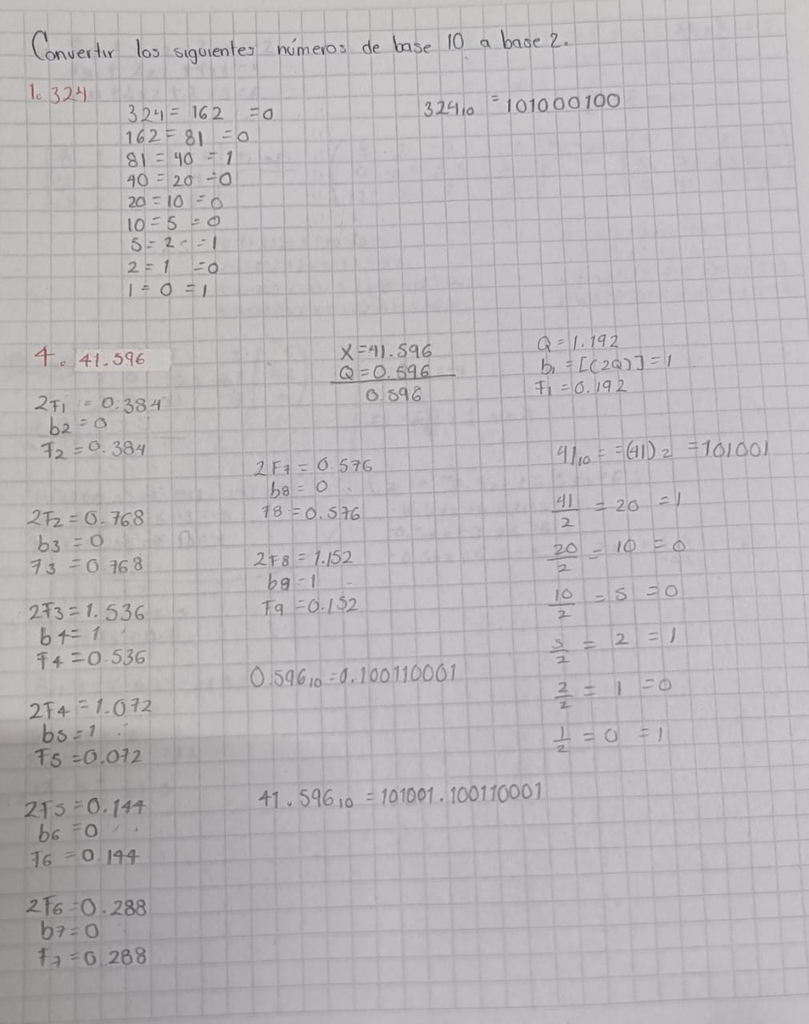

Ejercicio de base dos

#### Describe exhaustivamente los tipos de errores que existen

I. Errores Fundamentales y de Origen 1. Errores Inherentes (E_{inh}) Son los errores que residen en los datos de entrada del problema, independientes del método numérico empleado. * Definición: Imperfecciones en los valores iniciales debido a la naturaleza de su obtención. * Causas Primarias: * Imprecisión en la Medición: Limitaciones instrumentales en la obtención de datos empíricos. * Representación Irreversible: Necesidad de truncar o redondear constantes irracionales (, e) o fracciones no periódicas para su almacenamiento en formato de coma flotante.

# Sistemas de Ecuaciones lineales

## Metodos Directos

### Gauss simple

#### Ejercicio 1.

x1−2x2+0.5x3 = −5 −2x1+5x2−1.5x3 = 0 −0.2x1+1.75x2−x3 = 10

```r
A <- matrix(c(1, -2, 0.5,-2, 5, -1.5,-0.2, 1.75, -1), nrow = 3, byrow = TRUE)
```

```r
b <- matrix(c(-5, 0, 10), nrow = 3)
```

```r
Ab <- cbind(A, b)
cat("Matriz aumentada inicial:\n")
```

```
## Matriz aumentada inicial:
```

```r
print(Ab)
```

```
##      [,1]  [,2] [,3] [,4]
## [1,]  1.0 -2.00  0.5   -5
## [2,] -2.0  5.00 -1.5    0
## [3,] -0.2  1.75 -1.0   10
```

```r
m21 <- -Ab[2,1] / Ab[1,1]
m31 <- -Ab[3,1] / Ab[1,1]

Ab[2,] <- Ab[2,] + m21 * Ab[1,]
Ab[3,] <- Ab[3,] + m31 * Ab[1,]

cat("\nDespués de eliminar columna 1:\n")
```

```
##
## Después de eliminar columna 1:
```

```r
print(Ab)
```

```
##      [,1]  [,2] [,3] [,4]
## [1,]    1 -2.00  0.5   -5
## [2,]    0  1.00 -0.5  -10
## [3,]    0  1.35 -0.9    9
```

```r
m32 <- -Ab[3,2] / Ab[2,2]

Ab[3,] <- Ab[3,] + m32 * Ab[2,]

cat("\nDespués de eliminar columna 2:\n")
```

```
##
## Después de eliminar columna 2:
```

```r
print(Ab)
```

```
##      [,1] [,2]   [,3]  [,4]
## [1,]    1   -2  0.500  -5.0
## [2,]    0    1 -0.500 -10.0
## [3,]    0    0 -0.225  22.5
```

```r
z <- Ab[3,4] / Ab[3,3]
y <- (Ab[2,4] - Ab[2,3] * z) / Ab[2,2]
x <- (Ab[1,4] - Ab[1,2] * y - Ab[1,3] * z) / Ab[1,1]
```

```r
cat("\n--- Solución del sistema ---\n")
```

```
##
## --- Solución del sistema ---
```

```r
cat("x =", x, "\n")
```

```
## x = -75
```

```r
cat("y =", y, "\n")
```

```
## y = -60
```

```r
cat("z =", z, "\n")
```

```
## z = -100
```

#### Ejecicio 2.

3x1−x2+6x4 = 2.3 4x1+2x2−x3−5x4 = 6.9 −5x1+x2−3x3 = −36 10x2−4x3+7x4 = −36

```r
A <- matrix(c(3, -1, 0, 6,4, 2, -1, -5,-5, 1, -3, 0,0, 10, -4, 7),
            nrow = 4, byrow = TRUE)
```

```r
b <- matrix(c(2.3, 6.9, -36, -36), nrow = 4)
```

```r
Ab <- cbind(A, b)
cat("Matriz aumentada inicial (4x5):\n")
```

```
## Matriz aumentada inicial (4x5):
```

```r
print(Ab)
```

```
##      [,1] [,2] [,3] [,4]  [,5]
## [1,]    3   -1    0    6   2.3
## [2,]    4    2   -1   -5   6.9
## [3,]   -5    1   -3    0 -36.0
## [4,]    0   10   -4    7 -36.0
```

```r
m21 <- -Ab[2,1] / Ab[1,1]
m31 <- -Ab[3,1] / Ab[1,1]
m41 <- -Ab[4,1] / Ab[1,1]

Ab[2,] <- Ab[2,] + m21 * Ab[1,]
Ab[3,] <- Ab[3,] + m31 * Ab[1,]
Ab[4,] <- Ab[4,] + m41 * Ab[1,]

cat("\nDespués de eliminar columna 1:\n")
```

```
##
## Después de eliminar columna 1:
```

```r
print(Ab)
```

```
##      [,1]       [,2] [,3] [,4]       [,5]
## [1,]    3 -1.0000000    0    6   2.300000
## [2,]    0  3.3333333   -1  -13   3.833333
## [3,]    0 -0.6666667   -3   10 -32.166667
## [4,]    0 10.0000000   -4    7 -36.000000
```

```r
m32 <- -Ab[3,2] / Ab[2,2]

Ab[3,] <- Ab[3,] + m32 * Ab[2,]

cat("\nDespués de eliminar columna 2:\n")
```

```
##
## Después de eliminar columna 2:
```

```r
print(Ab)
```

```
##      [,1]      [,2] [,3]  [,4]       [,5]
## [1,]    3 -1.000000  0.0   6.0   2.300000
## [2,]    0  3.333333 -1.0 -13.0   3.833333
## [3,]    0  0.000000 -3.2   7.4 -31.400000
## [4,]    0 10.000000 -4.0   7.0 -36.000000
```

```r
m43 <- -Ab[4,3] / Ab[3,3]

Ab[4,] <- Ab[4,] + m43 * Ab[3,]

cat("\nDespués de eliminar columna 3 (Matriz Triangular Superior):\n")
```

```
##
## Después de eliminar columna 3 (Matriz Triangular Superior):
```

```r
print(Ab)
```

```
##      [,1]      [,2] [,3]   [,4]       [,5]
## [1,]    3 -1.000000  0.0   6.00   2.300000
## [2,]    0  3.333333 -1.0 -13.00   3.833333
## [3,]    0  0.000000 -3.2   7.40 -31.400000
## [4,]    0 10.000000  0.0  -2.25   3.250000
```

```r
x4 <- Ab[4,5] / Ab[4,4]
```

```r
x3 <- (Ab[3,5] - Ab[3,4] * x4) / Ab[3,3]
```

```r
x2 <- (Ab[2,5] - Ab[2,3] * x3 - Ab[2,4] * x4) / Ab[2,2]
```

```r
x1 <- (Ab[1,5] - Ab[1,2] * x2 - Ab[1,3] * x3 - Ab[1,4] * x4) / Ab[1,1]
```

```r
cat("\n--- Solución del sistema ---\n")
```

```
##
## --- Solución del sistema ---
```

```r
cat("x1 =", x1, "\n")
```

```
## x1 = 2.808333
```

```r
cat("x2 =", x2, "\n")
```

```
## x2 = -2.541667
```

```r
cat("x3 =", x3, "\n")
```

```
## x3 = 6.472222
```

```r
cat("x4 =", x4, "\n")
```

```
## x4 = -1.444444
```

#### Ejercicio 3.Utilizar redondeo a 4 cifras significativas.

0.003000x1+59.14x2 = 59.17 5.291x1−6.130x2 = 46.78

```r
redondeo <- function(num) {
  return(signif(num, digits = 4))
}
```

```r
A <- matrix(c(0.003000, 59.14, 5.291,-6.130), nrow = 2, byrow = TRUE)
```

```r
b <- matrix(c(59.17,46.78), nrow = 2)
```

```r
Ab <- cbind(A, b)
cat("### Matriz aumentada inicial ###\n")
```

```
## ### Matriz aumentada inicial ###
```

```r
print(Ab)
```

```
##       [,1]  [,2]  [,3]
## [1,] 0.003 59.14 59.17
## [2,] 5.291 -6.13 46.78
```

```r
m21 <- -Ab[2,1] / Ab[1,1]
m21 <- redondeo(m21)
cat("Multiplicador m21 (redondeado) =", m21, "\n")
```

```
## Multiplicador m21 (redondeado) = -1764
```

```r
m21_F1 <- numeric(3)
for (j in 1:3) {
  m21_F1[j] <- redondeo(m21 * Ab[1, j])
}
cat("m21 * F1 (productos redondeados) =", m21_F1, "\n")
```

```
## m21 * F1 (productos redondeados) = -5.292 -104300 -104400
```

```r
  Ab[2, j] <- redondeo(Ab[2, j] + m21_F1[j])
```

```r
cat("### Matriz después de la Eliminación ###\n")
```

```
## ### Matriz después de la Eliminación ###
```

```r
print(Ab)
```

```
##       [,1]  [,2]       [,3]
## [1,] 0.003 59.14      59.17
## [2,] 5.291 -6.13 -104400.00
```

```r
x2 <- Ab[2, 3] / Ab[2, 2]
x2 <- redondeo(x2)
cat("Cálculo de x2 (", Ab[2, 3], "/", Ab[2, 2], "): x2 =", x2, "\n")
```

```
## Cálculo de x2 ( -104400 / -6.13 ): x2 = 17030
```

```r
a12_x2 <- Ab[1, 2] * x2
a12_x2 <- redondeo(a12_x2)
cat("Cálculo a12*x2 (redondeado) =", a12_x2, "\n")
```

```
## Cálculo a12*x2 (redondeado) = 1007000
```

```r
numerador_x1 <- Ab[1, 3] - a12_x2
numerador_x1 <- redondeo(numerador_x1)
cat("Cálculo del Numerador (redondeado) =", numerador_x1, "\n")
```

```
## Cálculo del Numerador (redondeado) = -1007000
```

```r
x1 <- numerador_x1 / Ab[1, 1]
x1 <- redondeo(x1)
cat("Cálculo de x1 (", numerador_x1, "/", Ab[1, 1], "): x1 =", x1, "\n")
```

```
## Cálculo de x1 ( -1007000 / 0.003 ): x1 = -335700000
```

```r
cat("\n--- Solución del sistema ---\n")
```

```
##
## --- Solución del sistema ---
```

```r
cat("x1 =", x1, "\n")
```

```
## x1 = -335700000
```

```r
cat("x2 =", x2, "\n")
```

```
## x2 = 17030
```

#### Ejercicio 4.

4x1+2x2 = 2 2x1+3x2+x3 = −1 x2+5/2x3 = 3

```r
A <- matrix(c(4, 2, 0,2, 3, 1,0, 1, 5/2), nrow = 3, byrow = TRUE)
```

```r
b <- matrix(c(2, -1, 3), nrow = 3)
```

```r
Ab <- cbind(A, b)
cat("Matriz aumentada inicial:\n")
```

```
## Matriz aumentada inicial:
```

```r
print(Ab)
```

```
##      [,1] [,2] [,3] [,4]
## [1,]    4    2  0.0    2
## [2,]    2    3  1.0   -1
## [3,]    0    1  2.5    3
```

```r
m21 <- -Ab[2,1] / Ab[1,1]
Ab[2,] <- Ab[2,] + m21 * Ab[1,]
m31 <- -Ab[3,1] / Ab[1,1]
Ab[3,] <- Ab[3,] + m31 * Ab[1,]

cat("\nDespués de eliminar columna 1:\n")
```

```
##
## Después de eliminar columna 1:
```

```r
print(Ab)
```

```
##      [,1] [,2] [,3] [,4]
## [1,]    4    2  0.0    2
## [2,]    0    2  1.0   -2
## [3,]    0    1  2.5    3
```

```r
m32 <- -Ab[3,2] / Ab[2,2]
Ab[3,] <- Ab[3,] + m32 * Ab[2,]

cat("\nDespués de eliminar columna 2 (Matriz triangular superior):\n")
```

```
##
## Después de eliminar columna 2 (Matriz triangular superior):
```

```r
print(Ab)
```

```
##      [,1] [,2] [,3] [,4]
## [1,]    4    2    0    2
## [2,]    0    2    1   -2
## [3,]    0    0    2    4
```

```r
x3 <- Ab[3,4] / Ab[3,3]
x2 <- (Ab[2,4] - Ab[2,3] * x3) / Ab[2,2]
x1 <- (Ab[1,4] - Ab[1,2] * x2 - Ab[1,3] * x3) / Ab[1,1]
```

```r
cat("\n--- Solución del sistema (Eliminación Gaussiana Simple) ---\n")
```

```
##
## --- Solución del sistema (Eliminación Gaussiana Simple) ---
```

```r
cat("x1 =", x1, "\n")
```

```
## x1 = 1.5
```

```r
cat("x2 =", x2, "\n")
```

```
## x2 = -2
```

```r
cat("x3 =", x3, "\n")
```

```
## x3 = 2
```

#### Ejercicio 5.

3x1−0.1x2−0.2x3 = 7.85 0.1x1+7x2−0.3x3=−19.3 0.3x1−0.2x2+10x3 = 71.4

```r
A <- matrix(c(3, -0.1, -0.2,0.1, 7, -0.3,0.3, -0.2, 10), nrow = 3, byrow = TRUE)
```

```r
b <- matrix(c(7.85, -19.3, 71.4), nrow = 3)
```

```r
Ab <- cbind(A, b)
cat("### Matriz Aumentada Inicial (Ab):\n")
```

```
## ### Matriz Aumentada Inicial (Ab):
```

```r
print(Ab)
```

```
##      [,1] [,2] [,3]   [,4]
## [1,]  3.0 -0.1 -0.2   7.85
## [2,]  0.1  7.0 -0.3 -19.30
## [3,]  0.3 -0.2 10.0  71.40
```

```r
m21 <- Ab[2,1] / Ab[1,1]
m31 <- Ab[3,1] / Ab[1,1]

Ab[2,] <- Ab[2,] - m21 * Ab[1,]
Ab[3,] <- Ab[3,] - m31 * Ab[1,]

cat("\nDespués de eliminar columna 1 (Triangularidad parcial):\n")
```

```
##
## Después de eliminar columna 1 (Triangularidad parcial):
```

```r
print(Ab)
```

```
##      [,1]      [,2]       [,3]      [,4]
## [1,]    3 -0.100000 -0.2000000   7.85000
## [2,]    0  7.003333 -0.2933333 -19.56167
## [3,]    0 -0.190000 10.0200000  70.61500
```

```r
m32 <- Ab[3,2] / Ab[2,2]

Ab[3,] <- Ab[3,] - m32 * Ab[2,]

cat("\nDespués de eliminar columna 2 (Matriz Triangular Superior):\n")
```

```
##
## Después de eliminar columna 2 (Matriz Triangular Superior):
```

```r
print(Ab)
```

```
##      [,1]      [,2]       [,3]      [,4]
## [1,]    3 -0.100000 -0.2000000   7.85000
## [2,]    0  7.003333 -0.2933333 -19.56167
## [3,]    0  0.000000 10.0120419  70.08429
```

```r
x3 <- Ab[3,4] / Ab[3,3]

x2 <- (Ab[2,4] - Ab[2,3] * x3) / Ab[2,2]

x1 <- (Ab[1,4] - Ab[1,2] * x2 - Ab[1,3] * x3) / Ab[1,1]
```

```r
cat("\n--- Solución del sistema ---\n")
```

```
##
## --- Solución del sistema ---
```

```r
cat("x1 =", x1, "\n")
```

```
## x1 = 3
```

```r
cat("x2 =", x2, "\n")
```

```
## x2 = -2.5
```

```r
cat("x3 =", x3, "\n")
```

```
## x3 = 7
```

#### Ejercicio 9.

1.133x1+5.281x2−2.454x3 = 6.414 24.14x1−1.21x2+5.281x3 = 113.8 −10.123x1+6.387x2−x3 = 1

```r
A <- matrix(c(1.133, 5.281, -2.454,24.14, -1.21, 5.281,-10.123, 6.387, -1), nrow = 3, byrow = TRUE)
```

```r
b <- matrix(c(6.414, 113.8, 1), nrow = 3)
```

```r
Ab <- cbind(A, b)
cat("### Matriz Aumentada Inicial:\n")
```

```
## ### Matriz Aumentada Inicial:
```

```r
print(Ab)
```

```
##         [,1]   [,2]   [,3]    [,4]
## [1,]   1.133  5.281 -2.454   6.414
## [2,]  24.140 -1.210  5.281 113.800
## [3,] -10.123  6.387 -1.000   1.000
```

```r
m21 <- -Ab[2,1] / Ab[1,1]
m31 <- -Ab[3,1] / Ab[1,1]


Ab[2,] <- Ab[2,] + m21 * Ab[1,]
Ab[3,] <- Ab[3,] + m31 * Ab[1,]

cat("### Matriz después de eliminar x1 (Columna 1):\n")
```

```
## ### Matriz después de eliminar x1 (Columna 1):
```

```r
print(Ab)
```

```
##       [,1]       [,2]      [,3]      [,4]
## [1,] 1.133    5.28100  -2.45400   6.41400
## [2,] 0.000 -113.72839  57.56658 -22.85839
## [3,] 0.000   53.57108 -22.92572  58.30708
```

```r
m32 <- -Ab[3,2] / Ab[2,2]

Ab[3,] <- Ab[3,] + m32 * Ab[2,]

cat("### Matriz Triangular Superior (después de eliminar x2):\n")
```

```
## ### Matriz Triangular Superior (después de eliminar x2):
```

```r
print(Ab)
```

```
##       [,1]      [,2]      [,3]      [,4]
## [1,] 1.133    5.2810 -2.454000   6.41400
## [2,] 0.000 -113.7284 57.566578 -22.85839
## [3,] 0.000    0.0000  4.190672  47.53977
```

```r
x3 <- Ab[3,4] / Ab[3,3]
x2 <- (Ab[2,4] - Ab[2,3] * x3) / Ab[2,2]

x1 <- (Ab[1,4] - Ab[1,2] * x2 - Ab[1,3] * x3) / Ab[1,1]
```

```r
cat("### Solución del Sistema de Ecuaciones Lineales\n")
```

```
## ### Solución del Sistema de Ecuaciones Lineales
```

```r
cat("x1 =", x1, "\n")
```

```
## x1 = 2.530346
```

```r
cat("x2 =", x2, "\n")
```

```
## x2 = 5.943147
```

```r
cat("x3 =", x3, "\n")
```

```
## x3 = 11.34419
```

#### Ejercicio 10.

A=( 2 3 2 4 4 10 −4 0 −3 −2 −5 −2 −2 4 4 −7)

b=(9 −15 6 2)

```r
A <- matrix(c(2,3,2,4,4,10,-4,0,-3,-2,-5,-2,-2,4,4,-7), nrow = 4, byrow = TRUE)
```

```r
b <- matrix(c(9,-15,6,2), nrow = 4)
```

```r
Ab <- cbind(A, b)
cat("Matriz aumentada inicial:\n")
```

```
## Matriz aumentada inicial:
```

```r
print(Ab)
```

```
##      [,1] [,2] [,3] [,4] [,5]
## [1,]    2    3    2    4    9
## [2,]    4   10   -4    0  -15
## [3,]   -3   -2   -5   -2    6
## [4,]   -2    4    4   -7    2
```

```r
m21 <- -Ab[2,1] / Ab[1,1]
m31 <- -Ab[3,1] / Ab[1,1]
m41 <- -Ab[4,1] / Ab[1,1]

Ab[2,] <- Ab[2,] + m21 * Ab[1,]
Ab[3,] <- Ab[3,] + m31 * Ab[1,]
Ab[4,] <- Ab[4,] + m41 * Ab[1,]

cat("\nDespués de eliminar columna 1:\n")
```

```
##
## Después de eliminar columna 1:
```

```r
print(Ab)
```

```
##      [,1] [,2] [,3] [,4]  [,5]
## [1,]    2  3.0    2    4   9.0
## [2,]    0  4.0   -8   -8 -33.0
## [3,]    0  2.5   -2    4  19.5
## [4,]    0  7.0    6   -3  11.0
```

```r
m32 <- -Ab[3,2] / Ab[2,2]

Ab[3,] <- Ab[3,] + m32 * Ab[2,]

cat("\nDespués de eliminar columna 2:\n")
```

```
##
## Después de eliminar columna 2:
```

```r
print(Ab)
```

```
##      [,1] [,2] [,3] [,4]    [,5]
## [1,]    2    3    2    4   9.000
## [2,]    0    4   -8   -8 -33.000
## [3,]    0    0    3    9  40.125
## [4,]    0    7    6   -3  11.000
```

```r
m43 <- -Ab[4,3] / Ab[3,3]

Ab[4,] <- Ab[4,] + m43 * Ab[3,]

cat("\nDespués de eliminar columna 3 (Matriz Triangular Superior):\n")
```

```
##
## Después de eliminar columna 3 (Matriz Triangular Superior):
```

```r
print(Ab)
```

```
##      [,1] [,2] [,3] [,4]    [,5]
## [1,]    2    3    2    4   9.000
## [2,]    0    4   -8   -8 -33.000
## [3,]    0    0    3    9  40.125
## [4,]    0    7    0  -21 -69.250
```

```r
x4 <- Ab[4,5] / Ab[4,4]
```

```r
x3 <- (Ab[3,5] - Ab[3,4] * x4) / Ab[3,3]
```

```r
x2 <- (Ab[2,5] - Ab[2,3] * x3 - Ab[2,4] * x4) / Ab[2,2]
```

```r
x1 <- (Ab[1,5] - Ab[1,2] * x2 - Ab[1,3] * x3 - Ab[1,4] * x4) / Ab[1,1]
```

```r
cat("\n--- Solución del sistema ---\n")
```

```
##
## --- Solución del sistema ---
```

```r
cat("x1 =", x1, "\n")
```

```
## x1 = -13.54167
```

```r
cat("x2 =", x2, "\n")
```

```
## x2 = 5.309524
```

```r
cat("x3 =", x3, "\n")
```

```
## x3 = 3.482143
```

```r
cat("x4 =", x4, "\n")
```

```
## x4 = 3.297619
```

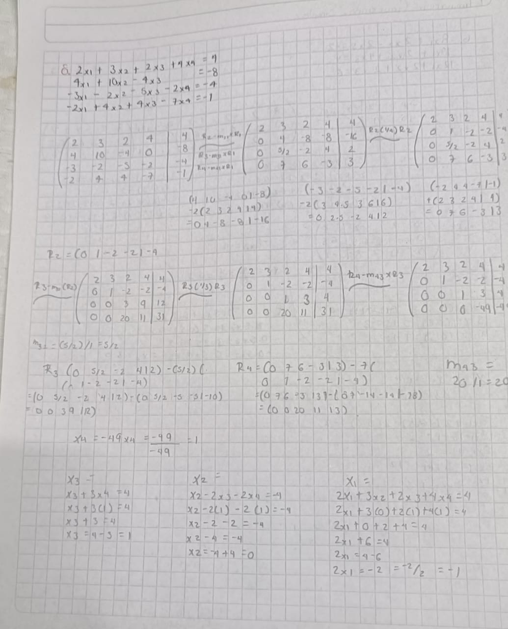

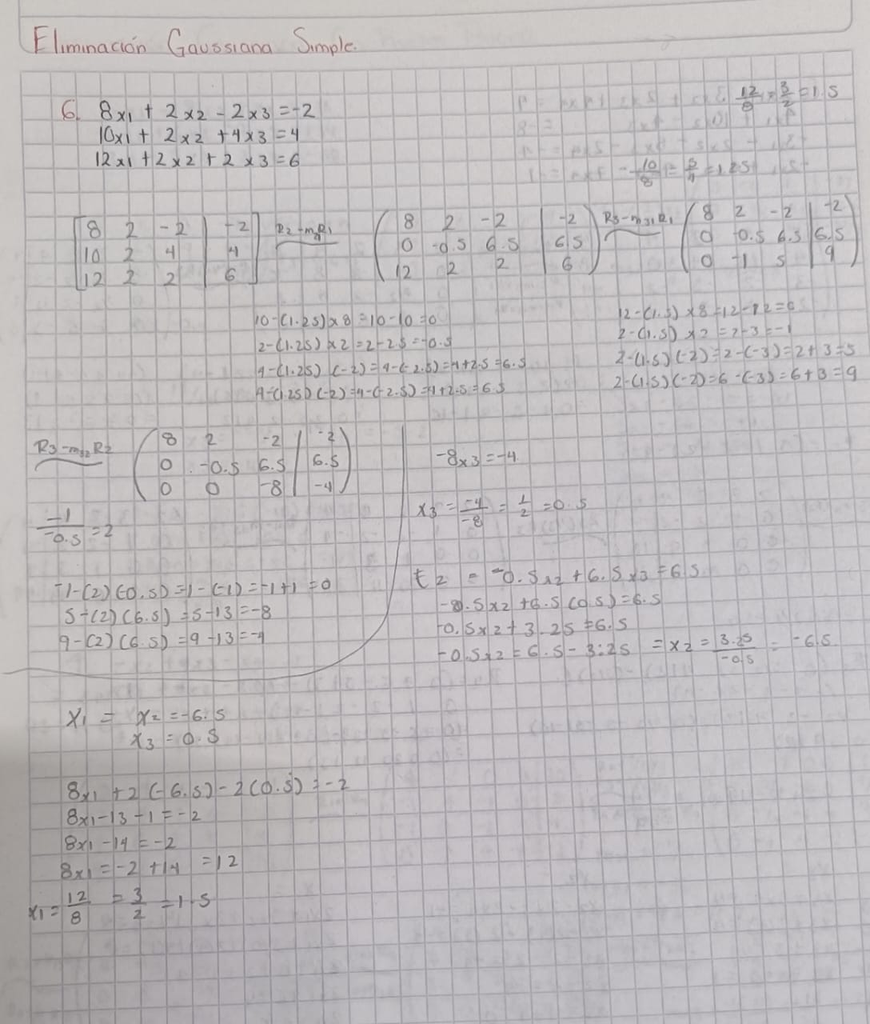

### Gauss con pivoteo parcial

#### Ejercicio 1.

0.4x1−1.5x2+0.75x3 = −20 −0.5x1−15x2+10x3 = −10 −10x1−9x2+2.5x3 = 30

```r
valores <- c(0.4, -0.5, -10, -1.5, -15, -9,0.75, 10, 2.5)
A <- matrix(valores, nrow = 3)
(A)
```

```
##       [,1]  [,2]  [,3]
## [1,]   0.4  -1.5  0.75
## [2,]  -0.5 -15.0 10.00
## [3,] -10.0  -9.0  2.50
```

```r
valoresb <- c(-20, -10, 30)
b <- matrix(valoresb, nrow = 3)
(b)
```

```
##      [,1]
## [1,]  -20
## [2,]  -10
## [3,]   30
```

```r
Ab <- cbind(A, b)
(Ab)
```

```
##       [,1]  [,2]  [,3] [,4]
## [1,]   0.4  -1.5  0.75  -20
## [2,]  -0.5 -15.0 10.00  -10
## [3,] -10.0  -9.0  2.50   30
```

```r
r1 <- Ab[3,]
r2 <- Ab[2,]
r3 <- Ab[1,]
nM <- rbind(r1, r2, r3)
(nM)
```

```
##     [,1]  [,2]  [,3] [,4]
## r1 -10.0  -9.0  2.50   30
## r2  -0.5 -15.0 10.00  -10
## r3   0.4  -1.5  0.75  -20
```

```r
m1 <- -nM[2,1] / nM[1,1]; m1
```

```
##    r2
## -0.05
```

```r
m2 <- -nM[3,1] / nM[1,1]; m2
```

```
##   r3
## 0.04
```

```r
A1 <- nM[1,]
A2 <- m1 * nM[1,] + nM[2,]
A3 <- m2 * nM[1,] + nM[3,]
NuevaA <- rbind(A1, A2, A3)
(NuevaA)
```

```
##    [,1]   [,2]  [,3]  [,4]
## A1  -10  -9.00 2.500  30.0
## A2    0 -14.55 9.875 -11.5
## A3    0  -1.86 0.850 -18.8
```

```r
m3 <- -NuevaA[3,2] / NuevaA[2,2]; m3
```

```
##         A3
## -0.1278351
```

```r
R1 <- NuevaA[1,]
R2 <- NuevaA[2,]
R3 <- m3 * NuevaA[2,] + NuevaA[3,]
Final <- rbind(R1, R2, R3)
(Final)
```

```
##    [,1]   [,2]       [,3]     [,4]
## R1  -10  -9.00  2.5000000  30.0000
## R2    0 -14.55  9.8750000 -11.5000
## R3    0   0.00 -0.4123711 -17.3299
```

```r
x3 <- Final[3,4] / Final[3,3]
x2 <- (Final[2,4] - Final[2,3]*x3) / Final[2,2]
x1 <- (Final[1,4] - Final[1,2]*x2 - Final[1,3]*x3) / Final[1,1]
```

```r
cat("Soluciones:\n")
```

```
## Soluciones:
```

```r
cat("x1 =", round(x1, 4), "\n")
```

```
## x1 = -18.875
```

```r
cat("x2 =", round(x2, 4), "\n")
```

```
## x2 = 29.3125
```

```r
cat("x3 =", round(x3, 4), "\n")
```

```
## x3 = 42.025
```

0.003000x1+59.14x2 = 59.17 5.291x1−6.130x2 = 46.78

```r
A <- matrix(c(0.003000, 59.14, 5.291, -6.130), nrow = 2, byrow = TRUE)
(A)
```

```
##       [,1]  [,2]
## [1,] 0.003 59.14
## [2,] 5.291 -6.13
```

```r
b <- matrix(c(59.17, 46.78), nrow = 2)
(b)
```

```
##       [,1]
## [1,] 59.17
## [2,] 46.78
```

```r
Ab <- cbind(A, b)
(Ab)
```

```
##       [,1]  [,2]  [,3]
## [1,] 0.003 59.14 59.17
## [2,] 5.291 -6.13 46.78
```

```r
if (abs(Ab[2,1]) > abs(Ab[1,1])) {
  Ab <- Ab[c(2,1), ]
}
cat("Matriz después del pivoteo parcial:\n")
```

```
## Matriz después del pivoteo parcial:
```

```r
print(Ab)
```

```
##       [,1]  [,2]  [,3]
## [1,] 5.291 -6.13 46.78
## [2,] 0.003 59.14 59.17
```

```r
m21 <- signif(-Ab[2,1] / Ab[1,1])
Ab[2, ] <- signif(Ab[2, ] + m21 * Ab[1, ])
cat("\nMatriz después de la eliminación:\n")
```

```
##
## Matriz después de la eliminación:
```

```r
print(Ab)
```

```
##            [,1]    [,2]    [,3]
## [1,]  5.291e+00 -6.1300 46.7800
## [2,] -2.291e-09 59.1435 59.1435
```

```r
x2 <- signif(Ab[2,3] / Ab[2,2])
x1 <- signif((Ab[1,3] - Ab[1,2]*x2) / Ab[1,1])
```

```r
cat("\nResultados:\n")
```

```
##
## Resultados:
```

```r
cat("x1 =", x1, "\n")
```

```
## x1 = 10
```

```r
cat("x2 =", x2, "\n")
```

```
## x2 = 1
```

#### Ejercicio 5.

0.00031000x1+1.000000x2 = 3.000000 1.00045534x1+1.00034333x2 = 7.000

```r
A <- matrix(c(0.00031000, 1.000000, 1.00045534, 1.00034333), nrow = 2, byrow = TRUE)
(A)
```

```
##          [,1]     [,2]
## [1,] 0.000310 1.000000
## [2,] 1.000455 1.000343
```

```r
b <- matrix(c(3.000000, 7.000000), nrow = 2)
(b)
```

```
##      [,1]
## [1,]    3
## [2,]    7
```

```r
Ab <- cbind(A, b)
cat("Matriz aumentada inicial:\n")
```

```
## Matriz aumentada inicial:
```

```r
print(Ab)
```

```
##          [,1]     [,2] [,3]
## [1,] 0.000310 1.000000    3
## [2,] 1.000455 1.000343    7
```

```r
if (abs(Ab[2,1]) > abs(Ab[1,1])) {
  temp <- Ab[1,]
  Ab[1,] <- Ab[2,]
  Ab[2,] <- temp
}
cat("Matriz después del pivoteo parcial:\n")
```

```
## Matriz después del pivoteo parcial:
```

```r
print(Ab)
```

```
##          [,1]     [,2] [,3]
## [1,] 1.000455 1.000343    7
## [2,] 0.000310 1.000000    3
```

```r
m <- -Ab[2,1] / Ab[1,1]
Ab[2,] <- Ab[2,] + m * Ab[1,]

cat("Matriz triangular superior:\n")
```

```
## Matriz triangular superior:
```

```r
print(Ab)
```

```
##          [,1]     [,2]     [,3]
## [1,] 1.000455 1.000343 7.000000
## [2,] 0.000000 0.999690 2.997831
```

```r
x2 <- Ab[2,3] / Ab[2,2]
x1 <- (Ab[1,3] - Ab[1,2]*x2) / Ab[1,1]
```

```r
cat("\nSolución del sistema:\n")
```

```
##
## Solución del sistema:
```

```r
cat("x1 =", x1, "\n")
```

```
## x1 = 3.998389
```

```r
cat("x2 =", x2, "\n")
```

```
## x2 = 2.99876
```

#### Ejercicio 7.

A=(1/4 1/5 1/6 1/3 1/4 1/5 1/2 1 2)

b=(9 8 8)

X=(x1 x2 x3)

```r
A_valores <- c(
  signif(1/4, 4), signif(1/5, 4), signif(1/6, 4),
  signif(1/3, 4), signif(1/4, 4), signif(1/5, 4),
  signif(1/2, 4), signif(1, 4), signif(2, 4)
)
```

```r
A <- matrix(A_valores, nrow = 3, byrow = TRUE)
cat("Matriz A (4 cifras):\n")
```

```
## Matriz A (4 cifras):
```

```r
print(A)
```

```
##        [,1] [,2]   [,3]
## [1,] 0.2500 0.20 0.1667
## [2,] 0.3333 0.25 0.2000
## [3,] 0.5000 1.00 2.0000
```

```r
b_valores <- c(9, 8, 8)
b <- matrix(b_valores, nrow = 3)
cat("\nVector b (4 cifras):\n")
```

```
##
## Vector b (4 cifras):
```

```r
print(b)
```

```
##      [,1]
## [1,]    9
## [2,]    8
## [3,]    8
```

```r
Ab <- cbind(A, b)
cat("\nMatriz Aumentada Inicial:\n")
```

```
##
## Matriz Aumentada Inicial:
```

```r
print(Ab)
```

```
##        [,1] [,2]   [,3] [,4]
## [1,] 0.2500 0.20 0.1667    9
## [2,] 0.3333 0.25 0.2000    8
## [3,] 0.5000 1.00 2.0000    8
```

```r
if (abs(Ab[2,1]) > abs(Ab[1,1]) || abs(Ab[3,1]) > abs(Ab[1,1])) {
  pivote_row <- 1
  if (abs(Ab[2,1]) > abs(Ab[pivote_row,1])) {
    pivote_row <- 2
  }
  if (abs(Ab[3,1]) > abs(Ab[pivote_row,1])) {
    pivote_row <- 3
  }
  if (pivote_row != 1) {
    Ab[c(1, pivote_row), ] <- Ab[c(pivote_row, 1), ]
  }
}
cat("\nMatriz después del Pivoteo Parcial (Columna 1):\n")
```

```
##
## Matriz después del Pivoteo Parcial (Columna 1):
```

```r
print(Ab)
```

```
##        [,1] [,2]   [,3] [,4]
## [1,] 0.5000 1.00 2.0000    8
## [2,] 0.3333 0.25 0.2000    8
## [3,] 0.2500 0.20 0.1667    9
```

```r
m21 <- signif(-Ab[2,1] / Ab[1,1], 4)
cat("\nMultiplicador m21 (4 cifras):", m21, "\n")
```

```
##
## Multiplicador m21 (4 cifras): -0.6666
```

```r
Ab[2, ] <- signif(Ab[2, ] + signif(m21 * Ab[1, ], 4), 4)
```

```r
m31 <- signif(-Ab[3,1] / Ab[1,1], 4)
cat("Multiplicador m31 (4 cifras):", m31, "\n")
```

```
## Multiplicador m31 (4 cifras): -0.5
```

```r
Ab[3, ] <- signif(Ab[3, ] + signif(m31 * Ab[1, ], 4), 4)

cat("\nMatriz después de la Eliminación (Columna 1):\n")
```

```
##
## Matriz después de la Eliminación (Columna 1):
```

```r
print(Ab)
```

```
##      [,1]    [,2]    [,3]  [,4]
## [1,]  0.5  1.0000  2.0000 8.000
## [2,]  0.0 -0.4166 -1.1330 2.667
## [3,]  0.0 -0.3000 -0.8333 5.000
```

```r
if (abs(Ab[3,2]) > abs(Ab[2,2])) {
  Ab[c(2, 3), ] <- Ab[c(3, 2), ]
}
cat("\nMatriz después del Pivoteo Parcial (Columna 2):\n")
```

```
##
## Matriz después del Pivoteo Parcial (Columna 2):
```

```r
print(Ab)
```

```
##      [,1]    [,2]    [,3]  [,4]
## [1,]  0.5  1.0000  2.0000 8.000
## [2,]  0.0 -0.4166 -1.1330 2.667
## [3,]  0.0 -0.3000 -0.8333 5.000
```

```r
m32 <- signif(-Ab[3,2] / Ab[2,2], 4)
cat("\nMultiplicador m32 (4 cifras):", m32, "\n")
```

```
##
## Multiplicador m32 (4 cifras): -0.7201
```

```r
Ab[3, ] <- signif(Ab[3, ] + signif(m32 * Ab[2, ], 4), 4)

cat("\nMatriz después de la Eliminación Final:\n")
```

```
##
## Matriz después de la Eliminación Final:
```

```r
print(Ab)
```

```
##      [,1]    [,2]    [,3]  [,4]
## [1,]  0.5  1.0000  2.0000 8.000
## [2,]  0.0 -0.4166 -1.1330 2.667
## [3,]  0.0  0.0000 -0.0174 3.079
```

```r
x3 <- signif(Ab[3,4] / Ab[3,3], 4)

x2_numerator <- signif(Ab[2,4] - signif(Ab[2,3] * x3, 4), 4)
x2 <- signif(x2_numerator / Ab[2,2], 4)

x1_term2 <- signif(Ab[1,2] * x2, 4)
x1_term3 <- signif(Ab[1,3] * x3, 4)
x1_numerator <- signif(Ab[1,4] - signif(x1_term2 + x1_term3, 4), 4)
x1 <- signif(x1_numerator / Ab[1,1], 4)
```

```r
cat("\n--- Soluciones (Redondeo a 4 Cifras Significativas) ---\n")
```

```
##
## --- Soluciones (Redondeo a 4 Cifras Significativas) ---
```

```r
cat("x1 =", x1, "\n")
```

```
## x1 = -225.6
```

```r
cat("x2 =", x2, "\n")
```

```
## x2 = 474.8
```

```r
cat("x3 =", x3, "\n")
```

```
## x3 = -177
```

#### Ejercicio 8.

A=( 1 1/2 1/3 1/4 1/2 1/3 1/4 1/5 1/3 1/4 1/5 1/6 1/4 1/5 1/6 1/7)

b=(1/6 1/7 1/8 1/9)

X=(x1 x2 x3 x4)

```r
A_frac <- matrix(c(
  1, 1/2, 1/3, 1/4,
  1/2, 1/3, 1/4, 1/5,
  1/3, 1/4, 1/5, 1/6,
  1/4, 1/5, 1/6, 1/7
), nrow = 4, byrow = TRUE)
```

```r
b_frac <- matrix(c(1/6, 1/7, 1/8, 1/9), nrow = 4)
```

```r
Ab <- signif(cbind(A_frac, b_frac), 4)

cat("Matriz Aumentada Inicial (redondeada a 4 cifras):\n")
```

```
## Matriz Aumentada Inicial (redondeada a 4 cifras):
```

```r
print(Ab)
```

```
##        [,1]   [,2]   [,3]   [,4]   [,5]
## [1,] 1.0000 0.5000 0.3333 0.2500 0.1667
## [2,] 0.5000 0.3333 0.2500 0.2000 0.1429
## [3,] 0.3333 0.2500 0.2000 0.1667 0.1250
## [4,] 0.2500 0.2000 0.1667 0.1429 0.1111
```

```r
n <- nrow(Ab)
for (k in 1:(n - 1)) {

  pivot_row <- k
  max_val <- abs(Ab[k, k])

  for (i in (k + 1):n) {
    if (abs(Ab[i, k]) > max_val) {
      max_val <- abs(Ab[i, k])
      pivot_row <- i
    }
  }
}
```

```r
  if (pivot_row != k) {
    Ab[c(k, pivot_row), ] <- Ab[c(pivot_row, k), ]
    cat(paste("\nIntercambio: Fila", k, "con Fila", pivot_row, "en la iteración", k, "\n"))
    print(Ab)
  }
```

```r
  for (i in (k + 1):n) {
    if (abs(Ab[i, k]) > max_val) {
      max_val <- abs(Ab[i, k])
      pivot_row <- i
    }
  }
```

```r
     if (pivot_row != k) {
    Ab[c(k, pivot_row), ] <- Ab[c(pivot_row, k), ]
    cat(paste("\nIntercambio: Fila", k, "con Fila", pivot_row, "en la iteración", k, "\n"))
    print(Ab)
  }
```

```r
X <- numeric(n)
X[n] <- signif(Ab[n, n + 1] / Ab[n, n], 4)
```

```r
for (i in (n - 1):1) {
  sum_val <- 0
  for (j in (i + 1):n) {

    sum_val <- sum_val + signif(Ab[i, j] * X[j], 4)
  }

  X[i] <- signif((Ab[i, n + 1] - sum_val) / Ab[i, i], 4)
}
```

```r
cat("\nResultados (redondeo a 4 cifras significativas):\n")
```

```
##
## Resultados (redondeo a 4 cifras significativas):
```

```r
cat("x1 =", X[1], "\n")
```

```
## x1 = -0.009754
```

```r
cat("x2 =", X[2], "\n")
```

```
## x2 = -0.02055
```

```r
cat("x3 =", X[3], "\n")
```

```
## x3 = -0.023
```

```r
cat("x4 =", X[4], "\n")
```

```
## x4 = 0.7775
```

#### Ejercicio 9.

2x1+x2−x3+x4−3x5 = 7 x1+2x3−x4+x5 = 2 −2x2−x3+x4−x5 = −5 3x1+x2−4x3+5x5 = 6 x1−x2−x3−x4+x5 = 3

```r
valores <- c(2,1,-1,1,-3,1,0,2,-1,1,0,-2,-1,1,-1,3,1,-4,0,5,1,-1,-1,-1,1)
A <- matrix(valores, nrow = 5, byrow = TRUE)
(A)
```

```
##      [,1] [,2] [,3] [,4] [,5]
## [1,]    2    1   -1    1   -3
## [2,]    1    0    2   -1    1
## [3,]    0   -2   -1    1   -1
## [4,]    3    1   -4    0    5
## [5,]    1   -1   -1   -1    1
```

```r
valoresb <- c(7,2,-5,6,3)
b <- matrix(valoresb, nrow = 5)
(b)
```

```
##      [,1]
## [1,]    7
## [2,]    2
## [3,]   -5
## [4,]    6
## [5,]    3
```

```r
Ab <- cbind(A,b)
(Ab)
```

```
##      [,1] [,2] [,3] [,4] [,5] [,6]
## [1,]    2    1   -1    1   -3    7
## [2,]    1    0    2   -1    1    2
## [3,]    0   -2   -1    1   -1   -5
## [4,]    3    1   -4    0    5    6
## [5,]    1   -1   -1   -1    1    3
```

```r
r1 <- Ab[1,]
r2 <- Ab[2,]
r3 <- Ab[3,]
r4 <- Ab[4,]
r5 <- Ab[5,]
nM <- rbind(r1,r2,r3,r4,r5)
(nM)
```

```
##    [,1] [,2] [,3] [,4] [,5] [,6]
## r1    2    1   -1    1   -3    7
## r2    1    0    2   -1    1    2
## r3    0   -2   -1    1   -1   -5
## r4    3    1   -4    0    5    6
## r5    1   -1   -1   -1    1    3
```

```r
c1 <- nM[,1]
c2 <- nM[,2]
c3 <- nM[,3]
c4 <- nM[,4]
c5 <- nM[,5]
a11 <- nM[1,1]
a22 <- nM[2,2]
a32 <- nM[3,2]
a23 <- nM[2,3]
a14 <- nM[1,4]
a24 <- nM[2,4]
```

```r
m1 <- -nM[2,1]/nM[1,1]
m2 <- -nM[3,1]/nM[1,1]
m3 <- -nM[4,1]/nM[1,1]
m4 <- -nM[5,1]/nM[1,1]

A1 <- nM[1,]
A2 <- m1*nM[1,] + nM[2,]
A3 <- m2*nM[1,] + nM[3,]
A4 <- m3*nM[1,] + nM[4,]
A5 <- m4*nM[1,] + nM[5,]

NuevaA <- rbind(A1,A2,A3,A4,A5)
(NuevaA)
```

```
##    [,1] [,2] [,3] [,4] [,5] [,6]
## A1    2  1.0 -1.0  1.0 -3.0  7.0
## A2    0 -0.5  2.5 -1.5  2.5 -1.5
## A3    0 -2.0 -1.0  1.0 -1.0 -5.0
## A4    0 -0.5 -2.5 -1.5  9.5 -4.5
## A5    0 -1.5 -0.5 -1.5  2.5 -0.5
```

```r
m5 <- -NuevaA[3,2]/NuevaA[2,2]
m6 <- -NuevaA[4,2]/NuevaA[2,2]
m7 <- -NuevaA[5,2]/NuevaA[2,2]

R1 <- NuevaA[1,]
R2 <- NuevaA[2,]
R3 <- m5*NuevaA[2,] + NuevaA[3,]
R4 <- m6*NuevaA[2,] + NuevaA[4,]
R5 <- m7*NuevaA[2,] + NuevaA[5,]

Nueva <- rbind(R1,R2,R3,R4,R5)
(Nueva)
```

```
##    [,1] [,2]  [,3] [,4]  [,5] [,6]
## R1    2  1.0  -1.0  1.0  -3.0  7.0
## R2    0 -0.5   2.5 -1.5   2.5 -1.5
## R3    0  0.0 -11.0  7.0 -11.0  1.0
## R4    0  0.0  -5.0  0.0   7.0 -3.0
## R5    0  0.0  -8.0  3.0  -5.0  4.0
```

```r
m8 <- -Nueva[4,3]/Nueva[3,3]
m9 <- -Nueva[5,3]/Nueva[3,3]

R1 <- Nueva[1,]
R2 <- Nueva[2,]
R3 <- Nueva[3,]
R4 <- m8*Nueva[3,] + Nueva[4,]
R5 <- m9*Nueva[3,] + Nueva[5,]

Nueva2 <- rbind(R1,R2,R3,R4,R5)
(Nueva2)
```

```
##    [,1] [,2]  [,3]      [,4]  [,5]      [,6]
## R1    2  1.0  -1.0  1.000000  -3.0  7.000000
## R2    0 -0.5   2.5 -1.500000   2.5 -1.500000
## R3    0  0.0 -11.0  7.000000 -11.0  1.000000
## R4    0  0.0   0.0 -3.181818  12.0 -3.454545
## R5    0  0.0   0.0 -2.090909   3.0  3.272727
```

```r
m10 <- -Nueva2[5,4]/Nueva2[4,4]

R1 <- Nueva2[1,]
R2 <- Nueva2[2,]
R3 <- Nueva2[3,]
R4 <- Nueva2[4,]
R5 <- m10*Nueva2[4,] + Nueva2[5,]

Final <- rbind(R1,R2,R3,R4,R5)
(Final)
```

```
##    [,1] [,2]  [,3]      [,4]       [,5]      [,6]
## R1    2  1.0  -1.0  1.000000  -3.000000  7.000000
## R2    0 -0.5   2.5 -1.500000   2.500000 -1.500000
## R3    0  0.0 -11.0  7.000000 -11.000000  1.000000
## R4    0  0.0   0.0 -3.181818  12.000000 -3.454545
## R5    0  0.0   0.0  0.000000  -4.885714  5.542857
```

```r
R1 <- Final[1,]
R2 <- Final[2,]
R3 <- Final[3,]
R4 <- Final[4,]
R5 <- Final[5,]

v <- R5[5] / R5[4]
z <- (R4[5] - R4[4]*v) / R4[3]
y <- (R3[5] - R3[3]*z - R3[4]*v) / R3[2]
x <- (R2[5] - R2[3]*z - R2[4]*v - R2[2]*y) / R2[1]
u <- (R1[5] - R1[2]*y - R1[3]*z - R1[4]*v - R1[1]*x) / R1[1]
```

```r
x1 <- u
x2 <- y
x3 <- z
x4 <- v
x5 <- R5[5]/R5[5]

x1; x2; x3; x4; x5
```

```
## [1] NaN
```

```
## [1] NaN
```

```
## [1] -Inf
```

```
## [1] -Inf
```

```
## [1] 1
```

#### Ejercicio 10.

3.333x1+15920x2−10.333x3 = 15913 2.222x1+16.71x29.612x2 = 28.544 1.5611x1+5.1791x2+1.6852x3 = 8.4254

```r
valores <- c(3.333, 15920, -10.333,2.222, 16.71, 9.612,1.5611, 5.1791, 1.6852)
A <- matrix(valores, nrow = 3, byrow = TRUE)
(A)
```

```
##        [,1]       [,2]     [,3]
## [1,] 3.3330 15920.0000 -10.3330
## [2,] 2.2220    16.7100   9.6120
## [3,] 1.5611     5.1791   1.6852
```

```r
valoresb <- c(15913, 28.544, 8.4254)
b <- matrix(valoresb, nrow = 3)
(b)
```

```
##            [,1]
## [1,] 15913.0000
## [2,]    28.5440
## [3,]     8.4254
```

```r
Ab <- cbind(A, b)
Ab
```

```
##        [,1]       [,2]     [,3]       [,4]
## [1,] 3.3330 15920.0000 -10.3330 15913.0000
## [2,] 2.2220    16.7100   9.6120    28.5440
## [3,] 1.5611     5.1791   1.6852     8.4254
```

```r
m1 <- -Ab[2,1] / Ab[1,1]; m1
```

```
## [1] -0.6666667
```

```r
m2 <- -Ab[3,1] / Ab[1,1]; m2
```

```
## [1] -0.4683768
```

```r
A1 <- Ab[1,]
A2 <- m1 * Ab[1,] + Ab[2,]
A3 <- m2 * Ab[1,] + Ab[3,]
NuevaA <- rbind(A1, A2, A3)
(NuevaA)
```

```
##     [,1]      [,2]       [,3]       [,4]
## A1 3.333  15920.00 -10.333000  15913.000
## A2 0.000 -10596.62  16.500667 -10580.123
## A3 0.000  -7451.38   6.524938  -7444.855
```

```r
m3 <- -NuevaA[3,2] / NuevaA[2,2]; m3
```

```
##         A3
## -0.7031844
```

```r
R1 <- NuevaA[1,]
R2 <- NuevaA[2,]
R3 <- m3 * NuevaA[2,] + NuevaA[3,]
Final <- rbind(R1, R2, R3)
(Final)
```

```
##     [,1]      [,2]       [,3]          [,4]
## R1 3.333  15920.00 -10.333000  15913.000000
## R2 0.000 -10596.62  16.500667 -10580.122667
## R3 0.000      0.00  -5.078073     -5.078073
```

```r
x3 <- Final[3,4] / Final[3,3]
(x3)
```

```
## R3
##  1
```

```r
x2 <- (Final[2,4] - Final[2,3]*x3) / Final[2,2]
(x2)
```

```
## R2
##  1
```

```r
x1 <- (Final[1,4] - Final[1,2]*x2 - Final[1,3]*x3) / Final[1,1]
(x1)
```

```
## R1
##  1
```

```r
cat("Soluciones:\n")
```

```
## Soluciones:
```

```r
cat("x1 =", x1, "\n")
```

```
## x1 = 1
```

```r
cat("x2 =", x2, "\n")
```

```
## x2 = 1
```

```r
cat("x3 =", x3, "\n")
```

```
## x3 = 1
```

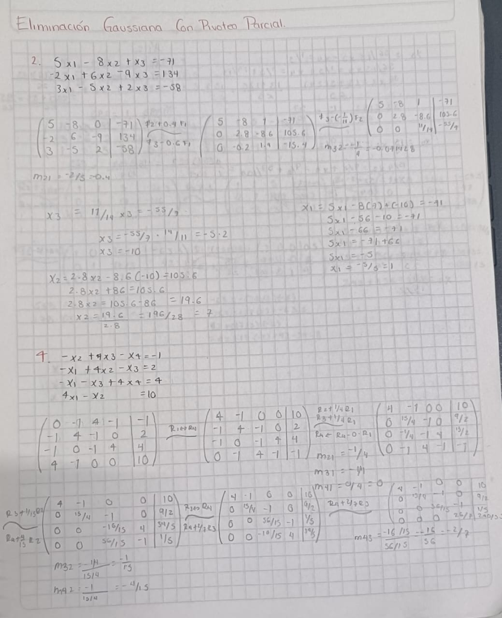

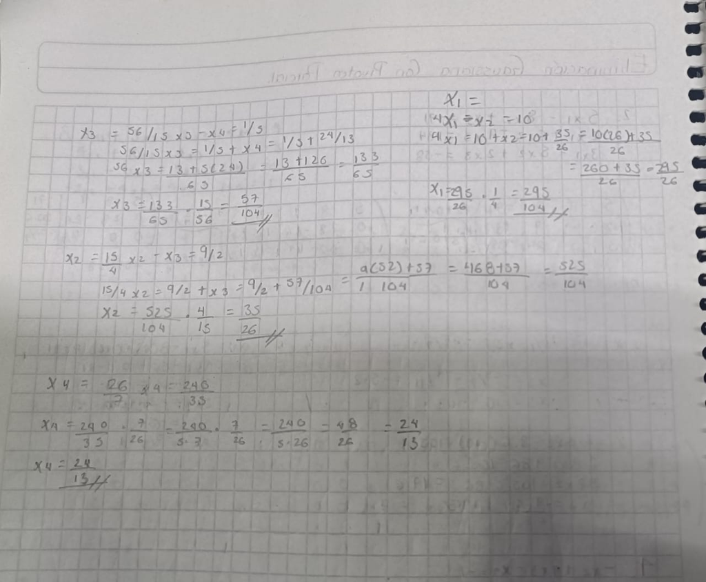

### Gauss Jordan

#### Ejercicio 1.

x1+2x2+3x3 = 1 −0.4x1+2x2−x3 = 10 0.5x1−3x2+x3 = 15

```r
valores <- c(0,2,3,-0.4,2,-0,0.5,-3,0)
A <- matrix(valores, nrow = 3, byrow = TRUE)
(A)
```

```
##      [,1] [,2] [,3]
## [1,]  0.0    2    3
## [2,] -0.4    2    0
## [3,]  0.5   -3    0
```

```r
valoresb <- c(1,10,15)
b <- matrix(valoresb, nrow = 3)
(b)
```

```
##      [,1]
## [1,]    1
## [2,]   10
## [3,]   15
```

```r
M <- matrix(c(
    1,   2,   3,    1,
    -0.4, 2,  -1,   10,
    0.5, -3,  1,    15
), nrow=3, byrow=TRUE)

print("--- Matriz Aumentada Inicial ---")
```

```
## [1] "--- Matriz Aumentada Inicial ---"
```

```r
print(M)
```

```
##      [,1] [,2] [,3] [,4]
## [1,]  1.0    2    3    1
## [2,] -0.4    2   -1   10
## [3,]  0.5   -3    1   15
```

```r
n <- nrow(M)
m <- n

for (j in 1:m) {
    pivote_val <- abs(M[j, j])
    pivote_row <- j

  if (j<n){
      for(i in (j+1):n){
        if (abs(M[i,j]) >
    pivote_val){
          pivote_val <-
            abs(M[i,j])
          pivote_row <- i
        }

      }

  }
}
```

```r
    if (pivote_row != j) {
        M[c(j, pivote_row),] <- M[c(pivote_row, j),]
        print(paste("--- Paso:", j, "Intercambio de Filas (R", j, " <-> R", pivote_row, ") ---"))
        print(M)
    }
```

```r
    if (M[j, j] == 0) {
        warning("El elemento pivote es cero. El sistema no tiene solución única o tiene infinitas soluciones.")
        next
    }
```

```r
    divisor <- M[j, j]
    M[j,] <- M[j,] / divisor

    print(paste("--- Paso:", j, "Normalización (R", j, " <- R", j, " /", round(divisor, 4), ") ---"))
```

```
## [1] "--- Paso: 3 Normalización (R 3  <- R 3  / 1 ) ---"
```

```r
    print(M)
```

```
##      [,1] [,2] [,3] [,4]
## [1,]  1.0    2    3    1
## [2,] -0.4    2   -1   10
## [3,]  0.5   -3    1   15
```

```r
    for (i in 1:n) {
        if (i != j) {
            factor <- M[i, j]
            M[i,] <- M[i,] - factor * M[j,]

            print(paste("--- Paso:", j, "Eliminación (R", i, " <- R", i, " -", round(factor, 4), " * R", j, ") ---"))
            print(M)
        }
    }
```

```
## [1] "--- Paso: 3 Eliminación (R 1  <- R 1  - 3  * R 3 ) ---"
##      [,1] [,2] [,3] [,4]
## [1,] -0.5   11    0  -44
## [2,] -0.4    2   -1   10
## [3,]  0.5   -3    1   15
## [1] "--- Paso: 3 Eliminación (R 2  <- R 2  - -1  * R 3 ) ---"
##      [,1] [,2] [,3] [,4]
## [1,] -0.5   11    0  -44
## [2,]  0.1   -1    0   25
## [3,]  0.5   -3    1   15
```

```r
print("--- Matriz Final en Forma Escalonada Reducida por Filas ---")
```

```
## [1] "--- Matriz Final en Forma Escalonada Reducida por Filas ---"
```

```r
print(M)
```

```
##      [,1] [,2] [,3] [,4]
## [1,] -0.5   11    0  -44
## [2,]  0.1   -1    0   25
## [3,]  0.5   -3    1   15
```

```r
x1 <- M[1, m + 1]
x2 <- M[2, m + 1]
x3 <- M[3, m + 1]
```

```r
print("--- Solución Final (x1, x2, x3) ---")
```

```
## [1] "--- Solución Final (x1, x2, x3) ---"
```

```r
print(paste("x1 =", round(x1, 4)))
```

```
## [1] "x1 = -44"
```

```r
print(paste("x2 =", round(x2, 4)))
```

```
## [1] "x2 = 25"
```

```r
print(paste("x3 =", round(x3, 4)))
```

```
## [1] "x3 = 15"
```

#### Ejercicio 2.

2x1−0.9x2+3x3 = −3.61 −0.5x1+0.1x2−x3 = 2.035 x1−6.35x2−0.45x3 = 15.401

```r
valores <- c(2,-0.9,3,-0.5,0.1,-0,0,-6.35,-0.45 )
A <- matrix(valores, nrow = 3, byrow = TRUE)
(A)
```

```
##      [,1]  [,2]  [,3]
## [1,]  2.0 -0.90  3.00
## [2,] -0.5  0.10  0.00
## [3,]  0.0 -6.35 -0.45
```

```r
b <- c(-3.61, 2.035, 15.401)
```

```r
M <- cbind(A, b)
print("--- Paso 1: Matriz Aumentada Inicial ---")
```

```
## [1] "--- Paso 1: Matriz Aumentada Inicial ---"
```

```r
print(M)
```

```
##                            b
## [1,]  2.0 -0.90  3.00 -3.610
## [2,] -0.5  0.10  0.00  2.035
## [3,]  0.0 -6.35 -0.45 15.401
```

```r
cat("\n")
```

```r
cat("--- Paso 2.1: Convertir M[1,1] en 1 (Pivote de la Fila 1) --- \n")
```

```
## --- Paso 2.1: Convertir M[1,1] en 1 (Pivote de la Fila 1) ---
```

```r
pivote_1 <- M[1, 1]
M[1, ] <- M[1, ] / pivote_1
print(M)
```

```
##                            b
## [1,]  1.0 -0.45  1.50 -1.805
## [2,] -0.5  0.10  0.00  2.035
## [3,]  0.0 -6.35 -0.45 15.401
```

```r
cat("\n")
```

```r
cat("--- Paso 2.2: Convertir M[2,1] en 0 --- \n")
```

```
## --- Paso 2.2: Convertir M[2,1] en 0 ---
```

```r
factor_21 <- M[2, 1]
M[2, ] <- M[2, ] - factor_21 * M[1, ]
print(M)
```

```
##                           b
## [1,] 1 -0.450  1.50 -1.8050
## [2,] 0 -0.125  0.75  1.1325
## [3,] 0 -6.350 -0.45 15.4010
```

```r
cat("\n")
```

```r
cat("--- Paso 2.3: Convertir M[3,1] en 0 --- \n")
```

```
## --- Paso 2.3: Convertir M[3,1] en 0 ---
```

```r
factor_31 <- M[3, 1]
M[3, ] <- M[3, ] - factor_31 * M[1, ]
print(M)
```

```
##                           b
## [1,] 1 -0.450  1.50 -1.8050
## [2,] 0 -0.125  0.75  1.1325
## [3,] 0 -6.350 -0.45 15.4010
```

```r
cat("\n")
```

```r
cat("--- Paso 2.4: Convertir M[2,2] en 1 (Pivote de la Fila 2) --- \n")
```

```
## --- Paso 2.4: Convertir M[2,2] en 1 (Pivote de la Fila 2) ---
```

```r
pivote_2 <- M[2, 2]
M[2, ] <- M[2, ] / pivote_2
print(M)
```

```
##                         b
## [1,] 1 -0.45  1.50 -1.805
## [2,] 0  1.00 -6.00 -9.060
## [3,] 0 -6.35 -0.45 15.401
```

```r
cat("\n")
```

```r
cat("--- Paso 2.5: Convertir M[3,2] en 0 --- \n")
```

```
## --- Paso 2.5: Convertir M[3,2] en 0 ---
```

```r
factor_32 <- M[3, 2]
M[3, ] <- M[3, ] - factor_32 * M[2, ]
print(M)
```

```
##                           b
## [1,] 1 -0.45   1.50  -1.805
## [2,] 0  1.00  -6.00  -9.060
## [3,] 0  0.00 -38.55 -42.130
```

```r
cat("\n")
```

```r
cat("--- Paso 2.6: Convertir M[3,3] en 1 (Pivote de la Fila 3) --- \n")
```

```
## --- Paso 2.6: Convertir M[3,3] en 1 (Pivote de la Fila 3) ---
```

```r
pivote_3 <- M[3, 3]
M[3, ] <- M[3, ] / pivote_3
print(M)
```

```
##                           b
## [1,] 1 -0.45  1.5 -1.805000
## [2,] 0  1.00 -6.0 -9.060000
## [3,] 0  0.00  1.0  1.092866
```

```r
cat("\n")
```

```r
cat("--- Paso 3.1: Convertir M[2,3] en 0 --- \n")
```

```
## --- Paso 3.1: Convertir M[2,3] en 0 ---
```

```r
factor_23 <- M[2, 3]
M[2, ] <- M[2, ] - factor_23 * M[3, ]
print(M)
```

```
##                          b
## [1,] 1 -0.45 1.5 -1.805000
## [2,] 0  1.00 0.0 -2.502802
## [3,] 0  0.00 1.0  1.092866
```

```r
cat("\n")
```

```r
cat("--- Paso 3.2: Convertir M[1,3] en 0 --- \n")
```

```
## --- Paso 3.2: Convertir M[1,3] en 0 ---
```

```r
factor_13 <- M[1, 3]
M[1, ] <- M[1, ] - factor_13 * M[3, ]
print(M)
```

```
##                        b
## [1,] 1 -0.45 0 -3.444300
## [2,] 0  1.00 0 -2.502802
## [3,] 0  0.00 1  1.092866
```

```r
cat("\n")
```

```r
cat("--- Paso 3.3: Convertir M[1,2] en 0 --- \n")
```

```
## --- Paso 3.3: Convertir M[1,2] en 0 ---
```

```r
factor_12 <- M[1, 2]
M[1, ] <- M[1, ] - factor_12 * M[2, ]
print(M)
```

```
##                    b
## [1,] 1 0 0 -4.570560
## [2,] 0 1 0 -2.502802
## [3,] 0 0 1  1.092866
```

```r
cat("\n")
```

```r
print("--- Paso 4: Matriz en la Forma Reducida por Filas (Identidad) ---")
```

```
## [1] "--- Paso 4: Matriz en la Forma Reducida por Filas (Identidad) ---"
```

```r
print(M)
```

```
##                    b
## [1,] 1 0 0 -4.570560
## [2,] 0 1 0 -2.502802
## [3,] 0 0 1  1.092866
```

```r
soluciones <- M[, 4]
nombres <- c("x1", "x2", "x3")
resultado <- data.frame(Variable = nombres, Valor = soluciones)
print("--- Solución Final del Sistema ---")
```

```
## [1] "--- Solución Final del Sistema ---"
```

```r
print(resultado)
```

```
##   Variable     Valor
## 1       x1 -4.570560
## 2       x2 -2.502802
## 3       x3  1.092866
```

#### Ejercicio 3.

0.7x1+2.7x2−6x3+0.7x4 = 1.6487 2x1−0.8x2+3x3−x4 = −2.342 −x1−1.5x2+1.4x3+3x4 = −4.189 7x2−1.56x3+x4=15.792

```r
valores <- c(0.7,2.7,-6,0.7,2,-0.8,3,-0,-0,-1.5,1.4,3,0,7,-1.56,0)
A <- matrix(valores, nrow = 4, byrow = TRUE)
(A)
```

```
##      [,1] [,2]  [,3] [,4]
## [1,]  0.7  2.7 -6.00  0.7
## [2,]  2.0 -0.8  3.00  0.0
## [3,]  0.0 -1.5  1.40  3.0
## [4,]  0.0  7.0 -1.56  0.0
```

```r
b <- c(1.6487,-2.342,-4.189,15.792)
```

```r
M <- cbind(A, b)
print("--- Paso 1: Matriz Aumentada Inicial ---")
```

```
## [1] "--- Paso 1: Matriz Aumentada Inicial ---"
```

```r
print(M)
```

```
##                               b
## [1,] 0.7  2.7 -6.00 0.7  1.6487
## [2,] 2.0 -0.8  3.00 0.0 -2.3420
## [3,] 0.0 -1.5  1.40 3.0 -4.1890
## [4,] 0.0  7.0 -1.56 0.0 15.7920
```

```r
cat("\n")
```

```r
A_aumentada <- matrix(c(0.7, 2.7, -6, 0.7, 1.6487,2, -0.8, 3, -1, -2.342,-1, -1.5, 1.4, 3, -4.189,0, 7, -1.56, 1, 15.792),nrow = 4,byrow = TRUE)
cat("--- Matriz Aumentada Inicial ---\n")
```

```
## --- Matriz Aumentada Inicial ---
```

```r
print(A_aumentada)
```

```
##      [,1] [,2]  [,3] [,4]    [,5]
## [1,]  0.7  2.7 -6.00  0.7  1.6487
## [2,]  2.0 -0.8  3.00 -1.0 -2.3420
## [3,] -1.0 -1.5  1.40  3.0 -4.1890
## [4,]  0.0  7.0 -1.56  1.0 15.7920
```

```r
# R1 = R1 / 0.7
A_aumentada[1, ] <- A_aumentada[1, ] / A_aumentada[1, 1]
cat("\n--- Después de R1 = R1 / (0.7) ---\n")
```

```
##
## --- Después de R1 = R1 / (0.7) ---
```

```r
print(A_aumentada)
```

```
##      [,1]      [,2]      [,3] [,4]      [,5]
## [1,]    1  3.857143 -8.571429    1  2.355286
## [2,]    2 -0.800000  3.000000   -1 -2.342000
## [3,]   -1 -1.500000  1.400000    3 -4.189000
## [4,]    0  7.000000 -1.560000    1 15.792000
```

```r
# R2 = R2 - 2 * R1
A_aumentada[2, ] <- A_aumentada[2, ] - 2 * A_aumentada[1, ]
# R3 = R3 - (-1) * R1  => R3 = R3 + R1
A_aumentada[3, ] <- A_aumentada[3, ] + A_aumentada[1, ]
# R4 ya tiene un cero
cat("\n--- Después de hacer ceros debajo del pivote (1,1) ---\n")
```

```
##
## --- Después de hacer ceros debajo del pivote (1,1) ---
```

```r
print(A_aumentada)
```

```
##      [,1]      [,2]      [,3] [,4]      [,5]
## [1,]    1  3.857143 -8.571429    1  2.355286
## [2,]    0 -8.514286 20.142857   -3 -7.052571
## [3,]    0  2.357143 -7.171429    4 -1.833714
## [4,]    0  7.000000 -1.560000    1 15.792000
```

```r
# El valor es A_aumentada[2, 2]
pivote_2_2 <- A_aumentada[2, 2]
A_aumentada[2, ] <- A_aumentada[2, ] / pivote_2_2
cat("\n--- Después de hacer el pivote (2,2) = 1 ---\n")
```

```
##
## --- Después de hacer el pivote (2,2) = 1 ---
```

```r
print(A_aumentada)
```

```
##      [,1]     [,2]      [,3]     [,4]       [,5]
## [1,]    1 3.857143 -8.571429 1.000000  2.3552857
## [2,]    0 1.000000 -2.365772 0.352349  0.8283221
## [3,]    0 2.357143 -7.171429 4.000000 -1.8337143
## [4,]    0 7.000000 -1.560000 1.000000 15.7920000
```

```r
# R1 = R1 - A_aumentada[1, 2] * R2
A_aumentada[1, ] <- A_aumentada[1, ] - A_aumentada[1, 2] * A_aumentada[2, ]
# R3 = R3 - A_aumentada[3, 2] * R2
A_aumentada[3, ] <- A_aumentada[3, ] - A_aumentada[3, 2] * A_aumentada[2, ]
# R4 = R4 - A_aumentada[4, 2] * R2
A_aumentada[4, ] <- A_aumentada[4, ] - A_aumentada[4, 2] * A_aumentada[2, ]
cat("\n--- Después de hacer ceros con el pivote (2,2) ---\n")
```

```
##
## --- Después de hacer ceros con el pivote (2,2) ---
```

```r
print(A_aumentada)
```

```
##      [,1] [,2]       [,3]       [,4]       [,5]
## [1,]    1    0  0.5536913 -0.3590604 -0.8396711
## [2,]    0    1 -2.3657718  0.3523490  0.8283221
## [3,]    0    0 -1.5949664  3.1694631 -3.7861879
## [4,]    0    0 15.0004027 -1.4664430  9.9937450
```

```r
# El valor es A_aumentada[3, 3]
pivote_3_3 <- A_aumentada[3, 3]
A_aumentada[3, ] <- A_aumentada[3, ] / pivote_3_3
cat("\n--- Después de hacer el pivote (3,3) = 1 ---\n")
```

```
##
## --- Después de hacer el pivote (3,3) = 1 ---
```

```r
print(A_aumentada)
```

```
##      [,1] [,2]       [,3]       [,4]       [,5]
## [1,]    1    0  0.5536913 -0.3590604 -0.8396711
## [2,]    0    1 -2.3657718  0.3523490  0.8283221
## [3,]    0    0  1.0000000 -1.9871660  2.3738355
## [4,]    0    0 15.0004027 -1.4664430  9.9937450
```

```r
# R1 = R1 - A_aumentada[1, 3] * R3
A_aumentada[1, ] <- A_aumentada[1, ] - A_aumentada[1, 3] * A_aumentada[3, ]
# R2 = R2 - A_aumentada[2, 3] * R3
A_aumentada[2, ] <- A_aumentada[2, ] - A_aumentada[2, 3] * A_aumentada[3, ]
# R4 = R4 - A_aumentada[4, 3] * R3
A_aumentada[4, ] <- A_aumentada[4, ] - A_aumentada[4, 3] * A_aumentada[3, ]
cat("\n--- Después de hacer ceros con el pivote (3,3) ---\n")
```

```
##
## --- Después de hacer ceros con el pivote (3,3) ---
```

```r
print(A_aumentada)
```

```
##      [,1] [,2] [,3]       [,4]       [,5]
## [1,]    1    0    0  0.7412161  -2.154043
## [2,]    0    1    0 -4.3488323   6.444275
## [3,]    0    0    1 -1.9871660   2.373835
## [4,]    0    0    0 28.3418473 -25.614743
```

```r
# El valor es A_aumentada[4, 4]
pivote_4_4 <- A_aumentada[4, 4]
A_aumentada[4, ] <- A_aumentada[4, ] / pivote_4_4
cat("\n--- Después de hacer el pivote (4,4) = 1 ---\n")
```

```
##
## --- Después de hacer el pivote (4,4) = 1 ---
```

```r
print(A_aumentada)
```

```
##      [,1] [,2] [,3]       [,4]       [,5]
## [1,]    1    0    0  0.7412161 -2.1540431
## [2,]    0    1    0 -4.3488323  6.4442752
## [3,]    0    0    1 -1.9871660  2.3738355
## [4,]    0    0    0  1.0000000 -0.9037782
```

```r
# R1 = R1 - A_aumentada[1, 4] * R4
A_aumentada[1, ] <- A_aumentada[1, ] - A_aumentada[1, 4] * A_aumentada[4, ]
# R2 = R2 - A_aumentada[2, 4] * R4
A_aumentada[2, ] <- A_aumentada[2, ] - A_aumentada[2, 4] * A_aumentada[4, ]
# R3 = R3 - A_aumentada[3, 4] * R4
A_aumentada[3, ] <- A_aumentada[3, ] - A_aumentada[3, 4] * A_aumentada[4, ]
cat("\n Después de hacer ceros con el pivote (4,4) \n")
```

```
##
##  Después de hacer ceros con el pivote (4,4)
```

```r
cat(" Forma Escalonada Reducida (Matriz Identidad) \n")
```

```
##  Forma Escalonada Reducida (Matriz Identidad)
```

```r
print(A_aumentada)
```

```
##      [,1] [,2] [,3] [,4]       [,5]
## [1,]    1    0    0    0 -1.4841482
## [2,]    0    1    0    0  2.5138955
## [3,]    0    0    1    0  0.5778782
## [4,]    0    0    0    1 -0.9037782
```

```r
solucion <- A_aumentada[, 5]
cat(sprintf("x1 = %f\n", solucion[1]))
```

```
## x1 = -1.484148
```

```r
cat(sprintf("x2 = %f\n", solucion[2]))
```

```
## x2 = 2.513895
```

```r
cat(sprintf("x3 = %f\n", solucion[3]))
```

```
## x3 = 0.577878
```

```r
cat(sprintf("x4 = %f\n", solucion[4]))
```

```
## x4 = -0.903778
```

```r
# Se redondea
cat("\n*** Solución Redondeada a 4 decimales: ***\n")
```

```
##
## *** Solución Redondeada a 4 decimales: ***
```

```r
cat(sprintf("x1 = %.4f\n", round(solucion[1], 4)))
```

```
## x1 = -1.4841
```

```r
cat(sprintf("x2 = %.4f\n", round(solucion[2], 4)))
```

```
## x2 = 2.5139
```

```r
cat(sprintf("x3 = %.4f\n", round(solucion[3], 4)))
```

```
## x3 = 0.5779
```

```r
cat(sprintf("x4 = %.4f\n", round(solucion[4], 4)))
```

```
## x4 = -0.9038
```

#### Ejercicio 4.

3x1−0.1x2−0.2x3 = 7.85 0.1x1+7x2−0.3x3 = −19.3 0.3x1−0.2x2+10x3 = 71.4

```r
valores <- c(3,-0.1,-0.2,0.1,7,-0.3,0.3,-0.2,10)
A <- matrix(valores, nrow = 3, byrow = TRUE)
(A)
```

```
##      [,1] [,2] [,3]
## [1,]  3.0 -0.1 -0.2
## [2,]  0.1  7.0 -0.3
## [3,]  0.3 -0.2 10.0
```

```r
b <- c(7.85,-19.3,71.4)
```

```r
A <- matrix(c(3, -0.1, -0.2, 7.85,0.1, 7, -0.3, -19.3,0.3, -0.2, 10, 71.4), nrow = 3, byrow = TRUE)
print("--- Matriz Aumentada Inicial ---")
```

```
## [1] "--- Matriz Aumentada Inicial ---"
```

```r
print(A)
```

```
##      [,1] [,2] [,3]   [,4]
## [1,]  3.0 -0.1 -0.2   7.85
## [2,]  0.1  7.0 -0.3 -19.30
## [3,]  0.3 -0.2 10.0  71.40
```

```r
n <- nrow(A)
m <- ncol(A)
```

```r
for (i in 1:n) {

  pivot <- A[i, i]

  if (abs(pivot) < 1e-9) {
    stop(paste("El pivote en la fila", i, "es cero. El sistema podría no tener solución única."))
  }
}

  A[i, ] <- A[i, ] / pivot

  cat("\n Paso", i, ": Normalizar el pivote A[", i, ",", i, "] a 1 \n")
```

```
##
##  Paso 3 : Normalizar el pivote A[ 3 , 3 ] a 1
```

```r
  print(A)
```

```
##      [,1]  [,2] [,3]   [,4]
## [1,] 3.00 -0.10 -0.2   7.85
## [2,] 0.10  7.00 -0.3 -19.30
## [3,] 0.03 -0.02  1.0   7.14
```

```r
  for (j in 1:n) {
    if (i != j) {


      factor <- A[j, i]


      A[j, ] <- A[j, ] - factor * A[i, ]
    }
  }

  cat("\n--- Paso", i, ": Eliminar el resto de elementos en la columna", i, "---\n")
```

```
##
## --- Paso 3 : Eliminar el resto de elementos en la columna 3 ---
```

```r
  print(A)
```

```
##       [,1]   [,2] [,3]    [,4]
## [1,] 3.006 -0.104    0   9.278
## [2,] 0.109  6.994    0 -17.158
## [3,] 0.030 -0.020    1   7.140
```

```r
print(" 4. Matriz en Forma Escalonada Reducida (Gauss-Jordan) ")
```

```
## [1] " 4. Matriz en Forma Escalonada Reducida (Gauss-Jordan) "
```

```r
print(A)
```

```
##       [,1]   [,2] [,3]    [,4]
## [1,] 3.006 -0.104    0   9.278
## [2,] 0.109  6.994    0 -17.158
## [3,] 0.030 -0.020    1   7.140
```

```r
solucion <- A[, m]

print("\n 5. Solución del Sistema ")
```

```
## [1] "\n 5. Solución del Sistema "
```

```r
cat("x1 =", solucion[1], "\n")
```

```
## x1 = 9.278
```

```r
cat("x2 =", solucion[2], "\n")
```

```
## x2 = -17.158
```

```r
cat("x3 =", solucion[3], "\n")
```

```
## x3 = 7.14
```

#### Ejercicio 6.

A= (1 3 −2 1 1 3 −1 2 0 1 −1 4 2 6 1 2)

b=(4 1 5 2)

```r
A <- matrix(c(1, 1, 0, 2,3, 3, 1, 6,-2, -1, -1, 1,1, 2, 4, 2), nrow = 4, byrow = FALSE)
```

```r
b <- c(4, 1, 5, 2)
```

```r
print("Matriz A:")
```

```
## [1] "Matriz A:"
```

```r
print(A)
```

```
##      [,1] [,2] [,3] [,4]
## [1,]    1    3   -2    1
## [2,]    1    3   -1    2
## [3,]    0    1   -1    4
## [4,]    2    6    1    2
```

```r
M <- cbind(A, b)
n <- nrow(M)
m <- ncol(M)

cat("\n### Matriz Aumentada Inicial [A | b] ###\n")
```

```
##
## ### Matriz Aumentada Inicial [A | b] ###
```

```r
print(M)
```

```
##               b
## [1,] 1 3 -2 1 4
## [2,] 1 3 -1 2 1
## [3,] 0 1 -1 4 5
## [4,] 2 6  1 2 2
```

```r
gauss_jordan_paso_a_paso <- function(M) {
    n <- nrow(M)
    for (k in 1:n) {
        pivote_val <- M[k, k]

        if (abs(pivot_val) < 1e-10) {

            if (all(M[k:n, k] == 0)) {
                cat(sprintf("\n Advertencia: Columna %d con ceros. El sistema podría no tener solución única.\n", k))
                next
            }
            stop(sprintf("Error: Pivote en M[%d,%d] es cero o muy cercano a cero. Se requiere intercambio de filas.", k, k))
        }
    }
}
```

```r
        for (i in (k + 1):n) {
            if (i > n) break

            factor <- M[i, k]

            M[i, ] <- M[i, ] - factor * M[k, ]

            cat(sprintf("\n### Paso %d.%d: Eliminación Debajo (Fila %d) ###\n", k * 2, i - k, i))
            cat(sprintf("Operación: F%d = F%d - (%.4f) * F%d\n", i, i, factor, k))
            print(M)
        }
```

```
##
## ### Paso 6.1: Eliminación Debajo (Fila 4) ###
## Operación: F4 = F4 - (1.0000) * F3
##                 b
## [1,] 1 3 -2  1  4
## [2,] 1 3 -1  2  1
## [3,] 0 1 -1  4  5
## [4,] 2 5  2 -2 -3
```

```r
    step_count <- 0
    for (k in n:2) {
        for (i in 1:(k - 1)) {
            factor <- M[i, k]
      if (abs(factor) > 1e-10) {

      M[i, ] <- M[i, ] - factor * M[k, ]
         step_count <- step_count + 1

                cat(sprintf("\n### Paso Atrás %d: Eliminación Arriba (Fila %d) ###\n", step_count, i))
                cat(sprintf("Operación: F%d = F%d - (%.4f) * F%d\n", i, i, factor, k))
                print(M)
            }
        }
    }
```

```
##
## ### Paso Atrás 1: Eliminación Arriba (Fila 1) ###
## Operación: F1 = F1 - (1.0000) * F4
##                   b
## [1,] -1 -2 -4  3  7
## [2,]  1  3 -1  2  1
## [3,]  0  1 -1  4  5
## [4,]  2  5  2 -2 -3
##
## ### Paso Atrás 2: Eliminación Arriba (Fila 2) ###
## Operación: F2 = F2 - (2.0000) * F4
##                   b
## [1,] -1 -2 -4  3  7
## [2,] -3 -7 -5  6  7
## [3,]  0  1 -1  4  5
## [4,]  2  5  2 -2 -3
##
## ### Paso Atrás 3: Eliminación Arriba (Fila 3) ###
## Operación: F3 = F3 - (4.0000) * F4
##                    b
## [1,] -1  -2 -4  3  7
## [2,] -3  -7 -5  6  7
## [3,] -8 -19 -9 12 17
## [4,]  2   5  2 -2 -3
##
## ### Paso Atrás 4: Eliminación Arriba (Fila 1) ###
## Operación: F1 = F1 - (-4.0000) * F3
##                      b
## [1,] -33 -78 -40 51 75
## [2,]  -3  -7  -5  6  7
## [3,]  -8 -19  -9 12 17
## [4,]   2   5   2 -2 -3
##
## ### Paso Atrás 5: Eliminación Arriba (Fila 2) ###
## Operación: F2 = F2 - (-5.0000) * F3
##                       b
## [1,] -33  -78 -40 51 75
## [2,] -43 -102 -50 66 92
## [3,]  -8  -19  -9 12 17
## [4,]   2    5   2 -2 -3
##
## ### Paso Atrás 6: Eliminación Arriba (Fila 1) ###
## Operación: F1 = F1 - (-78.0000) * F2
##                                b
## [1,] -3387 -8034 -3940 5199 7251
## [2,]   -43  -102   -50   66   92
## [3,]    -8   -19    -9   12   17
## [4,]     2     5     2   -2   -3
```

```r
        if (step_count > 0) {
            cat("\n--- Fin del Bloque de Eliminación hacia Atrás para la Columna ", k, " ---\n")
        }
```

```
##
## --- Fin del Bloque de Eliminación hacia Atrás para la Columna  2  ---
```

```r
    solucion <- M[, m]
    names(solucion) <- paste0("x", 1:n)

    cat("\n### Solución Final ###\n")
```

```
##
## ### Solución Final ###
```

```r
    cat("Dado que la matriz reducida final es:\n")
```

```
## Dado que la matriz reducida final es:
```

```r
    print(M)
```

```
##                                b
## [1,] -3387 -8034 -3940 5199 7251
## [2,]   -43  -102   -50   66   92
## [3,]    -8   -19    -9   12   17
## [4,]     2     5     2   -2   -3
```

```r
    cat("\nEsto corresponde al sistema:\n")
```

```
##
## Esto corresponde al sistema:
```

```r
    cat(sprintf("x1 = %.4f\n", solucion[1]))
```

```
## x1 = 7251.0000
```

```r
    cat(sprintf("x2 = %.4f\n", solucion[2]))
```

```
## x2 = 92.0000
```

```r
    cat(sprintf("x3 = %.4f\n", solucion[3]))
```

```
## x3 = 17.0000
```

```r
    cat(sprintf("x4 = %.4f\n", solucion[4]))
```

```
## x4 = -3.0000
```

#### Ejercicio 7.

6x1−x2−x3+4x4 = 17 x1−10x2+2x3−x4 = −17 3x1−2x2+8x3−x4 = 19 x1+x2+x3−5x4 = −14

```r
M <- matrix(c(6, -1, -1,  4,  17,1, -10,  2, -1, -17,3, -2,  8, -1,  19,1,  1,  1, -5, -14), nrow = 4, byrow = TRUE)
```

```r
print("--- Matriz Aumentada Inicial ---")
```

```
## [1] "--- Matriz Aumentada Inicial ---"
```

```r
print(M)
```

```
##      [,1] [,2] [,3] [,4] [,5]
## [1,]    6   -1   -1    4   17
## [2,]    1  -10    2   -1  -17
## [3,]    3   -2    8   -1   19
## [4,]    1    1    1   -5  -14
```

```r
cat("\n")
```

```r
m <- nrow(M)
n <- ncol(M)
```

```r
print("--- Paso 1: Intercambio F1 <-> F2 ---")
```

```
## [1] "--- Paso 1: Intercambio F1 <-> F2 ---"
```

```r
M[c(1, 2), ] <- M[c(2, 1), ]
print(M)
```

```
##      [,1] [,2] [,3] [,4] [,5]
## [1,]    1  -10    2   -1  -17
## [2,]    6   -1   -1    4   17
## [3,]    3   -2    8   -1   19
## [4,]    1    1    1   -5  -14
```

```r
cat("\n")
```

```r
print("--- Paso 2: Eliminar debajo de M[1, 1] ---")
```

```
## [1] "--- Paso 2: Eliminar debajo de M[1, 1] ---"
```

```r
M[2, ] <- M[2, ] - 6 * M[1, ]
print("F2 <- F2 - 6*F1")
```

```
## [1] "F2 <- F2 - 6*F1"
```

```r
print(M)
```

```
##      [,1] [,2] [,3] [,4] [,5]
## [1,]    1  -10    2   -1  -17
## [2,]    0   59  -13   10  119
## [3,]    3   -2    8   -1   19
## [4,]    1    1    1   -5  -14
```

```r
cat("\n")
```

```r
M[3, ] <- M[3, ] - 3 * M[1, ]
print("F3 <- F3 - 3*F1")
```

```
## [1] "F3 <- F3 - 3*F1"
```

```r
print(M)
```

```
##      [,1] [,2] [,3] [,4] [,5]
## [1,]    1  -10    2   -1  -17
## [2,]    0   59  -13   10  119
## [3,]    0   28    2    2   70
## [4,]    1    1    1   -5  -14
```

```r
cat("\n")
```

```r
M[4, ] <- M[4, ] - 1 * M[1, ]
print("F4 <- F4 - 1*F1")
```

```
## [1] "F4 <- F4 - 1*F1"
```

```r
print(M)
```

```
##      [,1] [,2] [,3] [,4] [,5]
## [1,]    1  -10    2   -1  -17
## [2,]    0   59  -13   10  119
## [3,]    0   28    2    2   70
## [4,]    0   11   -1   -4    3
```

```r
cat("\n")
```

```r
print("--- Paso 3: Crear 1 líder en M[2, 2] ---")
```

```
## [1] "--- Paso 3: Crear 1 líder en M[2, 2] ---"
```

```r
M[2, ] <- M[2, ] / M[2, 2]
print("F2 <- F2 / M[2, 2]")
```

```
## [1] "F2 <- F2 / M[2, 2]"
```

```r
print(M)
```

```
##      [,1] [,2]      [,3]       [,4]       [,5]
## [1,]    1  -10  2.000000 -1.0000000 -17.000000
## [2,]    0    1 -0.220339  0.1694915   2.016949
## [3,]    0   28  2.000000  2.0000000  70.000000
## [4,]    0   11 -1.000000 -4.0000000   3.000000
```

```r
cat("\n")
```

```r
print("--- Paso 4: Eliminar debajo de M[2, 2] ---")
```

```
## [1] "--- Paso 4: Eliminar debajo de M[2, 2] ---"
```

```r
M[3, ] <- M[3, ] - 28 * M[2, ]
print("F3 <- F3 - 28*F2")
```

```
## [1] "F3 <- F3 - 28*F2"
```

```r
print(M)
```

```
##      [,1] [,2]      [,3]       [,4]       [,5]
## [1,]    1  -10  2.000000 -1.0000000 -17.000000
## [2,]    0    1 -0.220339  0.1694915   2.016949
## [3,]    0    0  8.169492 -2.7457627  13.525424
## [4,]    0   11 -1.000000 -4.0000000   3.000000
```

```r
cat("\n")
```

```r
M[4, ] <- M[4, ] - 11 * M[2, ]
print("F4 <- F4 - 11*F2")
```

```
## [1] "F4 <- F4 - 11*F2"
```

```r
print(M)
```

```
##      [,1] [,2]      [,3]       [,4]       [,5]
## [1,]    1  -10  2.000000 -1.0000000 -17.000000
## [2,]    0    1 -0.220339  0.1694915   2.016949
## [3,]    0    0  8.169492 -2.7457627  13.525424
## [4,]    0    0  1.423729 -5.8644068 -19.186441
```

```r
cat("\n")
```

```r
print("--- Paso 5: Crear 1 líder en M[3, 3] ---")
```

```
## [1] "--- Paso 5: Crear 1 líder en M[3, 3] ---"
```

```r
M[3, ] <- M[3, ] / M[3, 3]
print("F3 <- F3 / M[3, 3]")
```

```
## [1] "F3 <- F3 / M[3, 3]"
```

```r
print(M)
```

```
##      [,1] [,2]      [,3]       [,4]       [,5]
## [1,]    1  -10  2.000000 -1.0000000 -17.000000
## [2,]    0    1 -0.220339  0.1694915   2.016949
## [3,]    0    0  1.000000 -0.3360996   1.655602
## [4,]    0    0  1.423729 -5.8644068 -19.186441
```

```r
cat("\n")
```

```r
print("--- Paso 6: Eliminar debajo de M[3, 3] ---")
```

```
## [1] "--- Paso 6: Eliminar debajo de M[3, 3] ---"
```

```r
M[4, ] <- M[4, ] - M[4, 3] * M[3, ]
print("F4 <- F4 - M[4, 3] * F3")
```

```
## [1] "F4 <- F4 - M[4, 3] * F3"
```

```r
print(M)
```

```
##      [,1] [,2]      [,3]       [,4]       [,5]
## [1,]    1  -10  2.000000 -1.0000000 -17.000000
## [2,]    0    1 -0.220339  0.1694915   2.016949
## [3,]    0    0  1.000000 -0.3360996   1.655602
## [4,]    0    0  0.000000 -5.3858921 -21.543568
```

```r
cat("\n")
```

```r
print("--- Paso 7: Crear 1 líder en M[4, 4] ---")
```

```
## [1] "--- Paso 7: Crear 1 líder en M[4, 4] ---"
```

```r
M[4, ] <- M[4, ] / M[4, 4]
print("F4 <- F4 / M[4, 4]")
```

```
## [1] "F4 <- F4 / M[4, 4]"
```

```r
print(M)
```

```
##      [,1] [,2]      [,3]       [,4]       [,5]
## [1,]    1  -10  2.000000 -1.0000000 -17.000000
## [2,]    0    1 -0.220339  0.1694915   2.016949
## [3,]    0    0  1.000000 -0.3360996   1.655602
## [4,]    0    0  0.000000  1.0000000   4.000000
```

```r
cat("\n")
```

```r
print("--- Paso 8: Eliminar encima de M[4, 4] (Columna 4) ---")
```

```
## [1] "--- Paso 8: Eliminar encima de M[4, 4] (Columna 4) ---"
```

```r
M[3, ] <- M[3, ] - M[3, 4] * M[4, ]
print("F3 <- F3 - M[3, 4] * F4")
```

```
## [1] "F3 <- F3 - M[3, 4] * F4"
```

```r
print(M)
```

```
##      [,1] [,2]      [,3]       [,4]       [,5]
## [1,]    1  -10  2.000000 -1.0000000 -17.000000
## [2,]    0    1 -0.220339  0.1694915   2.016949
## [3,]    0    0  1.000000  0.0000000   3.000000
## [4,]    0    0  0.000000  1.0000000   4.000000
```

```r
cat("\n")
```

```r
M[2, ] <- M[2, ] - M[2, 4] * M[4, ]
print("F2 <- F2 - M[2, 4] * F4")
```

```
## [1] "F2 <- F2 - M[2, 4] * F4"
```

```r
print(M)
```

```
##      [,1] [,2]      [,3] [,4]       [,5]
## [1,]    1  -10  2.000000   -1 -17.000000
## [2,]    0    1 -0.220339    0   1.338983
## [3,]    0    0  1.000000    0   3.000000
## [4,]    0    0  0.000000    1   4.000000
```

```r
cat("\n")
```

```r
M[1, ] <- M[1, ] - M[1, 4] * M[4, ]
print("F1 <- F1 - M[1, 4] * F4")
```

```
## [1] "F1 <- F1 - M[1, 4] * F4"
```

```r
print(M)
```

```
##      [,1] [,2]      [,3] [,4]       [,5]
## [1,]    1  -10  2.000000    0 -13.000000
## [2,]    0    1 -0.220339    0   1.338983
## [3,]    0    0  1.000000    0   3.000000
## [4,]    0    0  0.000000    1   4.000000
```

```r
cat("\n")
```

```r
print("--- Paso 9: Eliminar encima de M[3, 3] (Columna 3) ---")
```

```
## [1] "--- Paso 9: Eliminar encima de M[3, 3] (Columna 3) ---"
```

```r
M[2, ] <- M[2, ] - M[2, 3] * M[3, ]
print("F2 <- F2 - M[2, 3] * F3")
```

```
## [1] "F2 <- F2 - M[2, 3] * F3"
```

```r
print(M)
```

```
##      [,1] [,2] [,3] [,4] [,5]
## [1,]    1  -10    2    0  -13
## [2,]    0    1    0    0    2
## [3,]    0    0    1    0    3
## [4,]    0    0    0    1    4
```

```r
cat("\n")
```

```r
M[1, ] <- M[1, ] - M[1, 3] * M[3, ]
print("F1 <- F1 - M[1, 3] * F3")
```

```
## [1] "F1 <- F1 - M[1, 3] * F3"
```

```r
print(M)
```

```
##      [,1] [,2] [,3] [,4] [,5]
## [1,]    1  -10    0    0  -19
## [2,]    0    1    0    0    2
## [3,]    0    0    1    0    3
## [4,]    0    0    0    1    4
```

```r
cat("\n")
```

```r
print("--- Paso 10: Eliminar encima de M[2, 2] (Columna 2) ---")
```

```
## [1] "--- Paso 10: Eliminar encima de M[2, 2] (Columna 2) ---"
```

```r
M[1, ] <- M[1, ] - M[1, 2] * M[2, ]
print("F1 <- F1 - M[1, 2] * F2")
```

```
## [1] "F1 <- F1 - M[1, 2] * F2"
```

```r
print(M)
```

```
##      [,1] [,2] [,3] [,4] [,5]
## [1,]    1    0    0    0    1
## [2,]    0    1    0    0    2
## [3,]    0    0    1    0    3
## [4,]    0    0    0    1    4
```

```r
cat("\n")
```

```r
solucion <- M[, n]
names(solucion) <- c("x1", "x2", "x3", "x4")

print("Solución:")
```

```
## [1] "Solución:"
```

```r
print(solucion)
```

```
## x1 x2 x3 x4
##  1  2  3  4
```

#### Ejercicio 10.

15x1−18x2+15x3−3x4 = 11 −18x1+242−18x3+4x4 = 10 15x1−18x2+18x3−3x4 = 11 −3x1+4x2−3x3+x4 = 13

```r
M <- matrix(c(15, -18,  15, -3,11,-18,  24, -18,4,10,15, -18,  18, -3,  11,
  -3,   4,  -3,  1,  13
), nrow = 4, byrow = TRUE)
```

```r
cat("### Matriz Aumentada Inicial ###\n")
```

```
## ### Matriz Aumentada Inicial ###
```

```r
print(M)
```

```
##      [,1] [,2] [,3] [,4] [,5]
## [1,]   15  -18   15   -3   11
## [2,]  -18   24  -18    4   10
## [3,]   15  -18   18   -3   11
## [4,]   -3    4   -3    1   13
```

```r
M[1, ] <- M[1, ] / M[1, 1]

cat("### Paso 2a: Fila 1 / M[1,1] (Pivot 1 = 1) ###\n")
```

```
## ### Paso 2a: Fila 1 / M[1,1] (Pivot 1 = 1) ###
```

```r
print(M)
```

```
##      [,1]  [,2] [,3] [,4]       [,5]
## [1,]    1  -1.2    1 -0.2  0.7333333
## [2,]  -18  24.0  -18  4.0 10.0000000
## [3,]   15 -18.0   18 -3.0 11.0000000
## [4,]   -3   4.0   -3  1.0 13.0000000
```

```r
M[2, ] <- M[2, ] - M[2, 1] * M[1, ]
M[3, ] <- M[3, ] - M[3, 1] * M[1, ]
M[4, ] <- M[4, ] - M[4, 1] * M[1, ]

cat("### Hacer 0's debajo del Pivote 1 (Columna 1) ###\n")
```

```
## ### Hacer 0's debajo del Pivote 1 (Columna 1) ###
```

```r
print(M)
```

```
##      [,1] [,2] [,3] [,4]       [,5]
## [1,]    1 -1.2    1 -0.2  0.7333333
## [2,]    0  2.4    0  0.4 23.2000000
## [3,]    0  0.0    3  0.0  0.0000000
## [4,]    0  0.4    0  0.4 15.2000000
```

```r
M[2, ] <- M[2, ] / M[2, 2]

cat("### Fila 2 / M[2,2] (Pivot 2 = 1) ###\n")
```

```
## ### Fila 2 / M[2,2] (Pivot 2 = 1) ###
```

```r
print(M)
```

```
##      [,1] [,2] [,3]       [,4]       [,5]
## [1,]    1 -1.2    1 -0.2000000  0.7333333
## [2,]    0  1.0    0  0.1666667  9.6666667
## [3,]    0  0.0    3  0.0000000  0.0000000
## [4,]    0  0.4    0  0.4000000 15.2000000
```

```r
M[3, ] <- M[3, ] - M[3, 2] * M[2, ]
M[4, ] <- M[4, ] - M[4, 2] * M[2, ]

cat("### Hacer 0's debajo de la columna 2 ###\n")
```

```
## ### Hacer 0's debajo de la columna 2 ###
```

```r
print(M)
```

```
##      [,1] [,2] [,3]       [,4]       [,5]
## [1,]    1 -1.2    1 -0.2000000  0.7333333
## [2,]    0  1.0    0  0.1666667  9.6666667
## [3,]    0  0.0    3  0.0000000  0.0000000
## [4,]    0  0.0    0  0.3333333 11.3333333
```

```r
M[3, ] <- M[3, ] / M[3, 3]

cat("### Paso 2e: Fila 3 / M[3,3] (Pivot 3 = 1) ###\n")
```

```
## ### Paso 2e: Fila 3 / M[3,3] (Pivot 3 = 1) ###
```

```r
print(M)
```

```
##      [,1] [,2] [,3]       [,4]       [,5]
## [1,]    1 -1.2    1 -0.2000000  0.7333333
## [2,]    0  1.0    0  0.1666667  9.6666667
## [3,]    0  0.0    1  0.0000000  0.0000000
## [4,]    0  0.0    0  0.3333333 11.3333333
```

```r
M[4, ] <- M[4, ] - M[4, 3] * M[3, ]

cat("### Hacer 0's debajo de la Columna 3 ###\n")
```

```
## ### Hacer 0's debajo de la Columna 3 ###
```

```r
print(M)
```

```
##      [,1] [,2] [,3]       [,4]       [,5]
## [1,]    1 -1.2    1 -0.2000000  0.7333333
## [2,]    0  1.0    0  0.1666667  9.6666667
## [3,]    0  0.0    1  0.0000000  0.0000000
## [4,]    0  0.0    0  0.3333333 11.3333333
```

```r
M[4, ] <- M[4, ] / M[4, 4]

cat("### Fila 4 / M[4,4] (Pivot 4 = 1) ###\n")
```

```
## ### Fila 4 / M[4,4] (Pivot 4 = 1) ###
```

```r
print(M)
```

```
##      [,1] [,2] [,3]       [,4]       [,5]
## [1,]    1 -1.2    1 -0.2000000  0.7333333
## [2,]    0  1.0    0  0.1666667  9.6666667
## [3,]    0  0.0    1  0.0000000  0.0000000
## [4,]    0  0.0    0  1.0000000 34.0000000
```

```r
cat("\n### Matriz en Forma Escalonada ###\n")
```

```
##
## ### Matriz en Forma Escalonada ###
```

```r
print(M)
```

```
##      [,1] [,2] [,3]       [,4]       [,5]
## [1,]    1 -1.2    1 -0.2000000  0.7333333
## [2,]    0  1.0    0  0.1666667  9.6666667
## [3,]    0  0.0    1  0.0000000  0.0000000
## [4,]    0  0.0    0  1.0000000 34.0000000
```

```r
M[3, ] <- M[3, ] - M[3, 4] * M[4, ]
M[2, ] <- M[2, ] - M[2, 4] * M[4, ]
M[1, ] <- M[1, ] - M[1, 4] * M[4, ]

cat("### Paso 3a: Hacer 0's arriba del Pivote 4 (Columna 4) ###\n")
```

```
## ### Paso 3a: Hacer 0's arriba del Pivote 4 (Columna 4) ###
```

```r
print(M)
```

```
##      [,1] [,2] [,3] [,4]      [,5]
## [1,]    1 -1.2    1    0  7.533333
## [2,]    0  1.0    0    0  4.000000
## [3,]    0  0.0    1    0  0.000000
## [4,]    0  0.0    0    1 34.000000
```

```r
M[2, ] <- M[2, ] - M[2, 3] * M[3, ]
M[1, ] <- M[1, ] - M[1, 3] * M[3, ]

cat("### Paso 3b: Hacer 0's arriba de la Columna 3 ###\n")
```

```
## ### Paso 3b: Hacer 0's arriba de la Columna 3 ###
```

```r
print(M)
```

```
##      [,1] [,2] [,3] [,4]      [,5]
## [1,]    1 -1.2    0    0  7.533333
## [2,]    0  1.0    0    0  4.000000
## [3,]    0  0.0    1    0  0.000000
## [4,]    0  0.0    0    1 34.000000
```

```r
M[1, ] <- M[1, ] - M[1, 2] * M[2, ]

cat("### Hacer 0's arriba de la Columna 2 ###\n")
```

```
## ### Hacer 0's arriba de la Columna 2 ###
```

```r
print(M)
```

```
##      [,1] [,2] [,3] [,4]     [,5]
## [1,]    1    0    0    0 12.33333
## [2,]    0    1    0    0  4.00000
## [3,]    0    0    1    0  0.00000
## [4,]    0    0    0    1 34.00000
```

```r
cat("### Matriz Final en Forma Escalonada Reducida ###\n")
```

```
## ### Matriz Final en Forma Escalonada Reducida ###
```

```r
print(M)
```

```
##      [,1] [,2] [,3] [,4]     [,5]
## [1,]    1    0    0    0 12.33333
## [2,]    0    1    0    0  4.00000
## [3,]    0    0    1    0  0.00000
## [4,]    0    0    0    1 34.00000
```

```r
solucion <- M[, 5]

cat("### Solución del Sistema (x1, x2, x3, x4) ###\n")
```

```
## ### Solución del Sistema (x1, x2, x3, x4) ###
```

```r
cat("x1 =", solucion[1], "\n")
```

```
## x1 = 12.33333
```

```r
cat("x2 =", solucion[2], "\n")
```

```
## x2 = 4
```

```r
cat("x3 =", solucion[3], "\n")
```

```
## x3 = 0
```

```r
cat("x4 =", solucion[4], "\n")
```

```
## x4 = 34
```

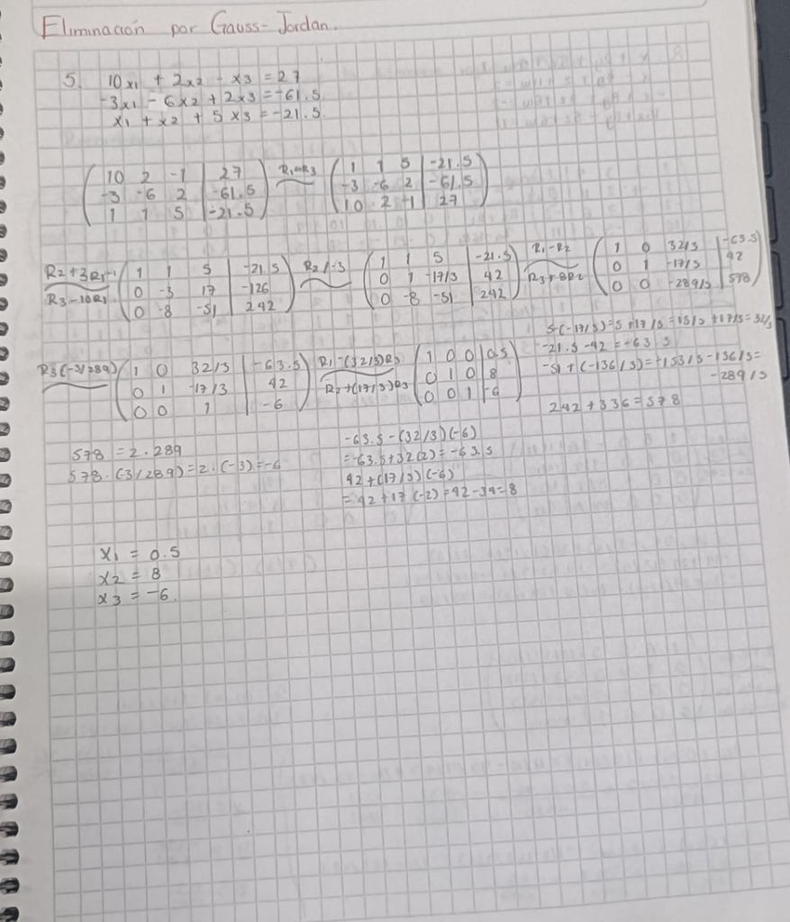

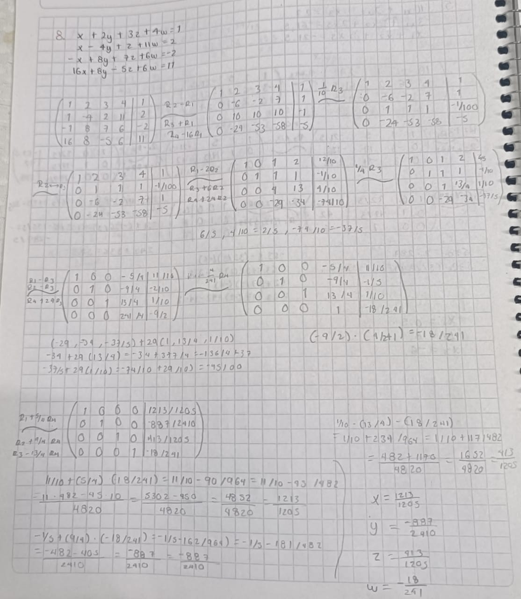

## Metodos Interativos

### Gauss-seidel

#### Ejercicio 1.

3x1−0.2x2−0.5x3 = 8 0.1x1+7x2+0.4x3 = −19.5 0.4x1−0.1x2+10x3 = 72.4

```r
A <- matrix(c(3,-0.2,-0.5,0.1,  7,0.4,0.4, -0.1, 10), nrow = 3, byrow = TRUE)
b <- c(8, -19.5, 72.4)
```

```r
x <- rep(0, 3)   # x^(0) = (0,0,0)
tol <- 1e-8
maxiter <- 100

cat("x^(0) =", paste(sprintf("%.10f", x), collapse = ", "), "\n\n")
```

```
## x^(0) = 0.0000000000, 0.0000000000, 0.0000000000
```

```r
# --- Iteración 1 ---
x_old <- x
# fila 1
s1 <- 0
s2 <- sum(A[1,2:3] * x_old[2:3])   # -0.2*x2_old + -0.5*x3_old
x[1] <- (b[1] - s1 - s2) / A[1,1]
cat("Iteración 1 - x1 =", sprintf("%.10f", x[1]), "\n")
```

```
## Iteración 1 - x1 = 2.6666666667
```

```r
# fila 2
s1 <- A[2,1] * x[1]                 # 0.1*x1_new
s2 <- A[2,3] * x_old[3]            # 0.4*x3_old
x[2] <- (b[2] - s1 - s2) / A[2,2]
cat("Iteración 1 - x2 =", sprintf("%.10f", x[2]), "\n")
```

```
## Iteración 1 - x2 = -2.8238095238
```

```r
# fila 3
s1 <- A[3,1] * x[1] + A[3,2] * x[2] # 0.4*x1_new + -0.1*x2_new
s2 <- 0
x[3] <- (b[3] - s1 - s2) / A[3,3]
cat("Iteración 1 - x3 =", sprintf("%.10f", x[3]), "\n")
```

```
## Iteración 1 - x3 = 7.1050952381
```

```r
cat("x^(1) =", paste(sprintf("%.10f", x), collapse = ", "), "\n\n")
```

```
## x^(1) = 2.6666666667, -2.8238095238, 7.1050952381
```

```r
# --- Iteración 2  ---
x_old <- x
# fila 1
s1 <- 0
s2 <- sum(A[1,2:3] * x_old[2:3])
x[1] <- (b[1] - s1 - s2) / A[1,1]
cat("Iteración 2 - x1 =", sprintf("%.10f", x[1]), "\n")
```

```
## Iteración 2 - x1 = 3.6625952381
```

```r
# fila 2
s1 <- A[2,1] * x[1]
s2 <- A[2,3] * x_old[3]
x[2] <- (b[2] - s1 - s2) / A[2,2]
cat("Iteración 2 - x2 =", sprintf("%.10f", x[2]), "\n")
```

```
## Iteración 2 - x2 = -3.2440425170
```

```r
# fila 3
s1 <- A[3,1] * x[1] + A[3,2] * x[2]
s2 <- 0
x[3] <- (b[3] - s1 - s2) / A[3,3]
cat("Iteración 2 - x3 =", sprintf("%.10f", x[3]), "\n")
```

```
## Iteración 2 - x3 = 7.0610557653
```

```r
cat("x^(2) =", paste(sprintf("%.10f", x), collapse = ", "), "\n\n")
```

```
## x^(2) = 3.6625952381, -3.2440425170, 7.0610557653
```

```r
# --- Iteración 3 ---
x_old <- x
s1 <- 0
s2 <- sum(A[1,2:3] * x_old[2:3])
x[1] <- (b[1] - s1 - s2) / A[1,1]
cat("Iteración 3 - x1 =", sprintf("%.10f", x[1]), "\n")
```

```
## Iteración 3 - x1 = 3.6272397931
```

```r
s1 <- A[2,1] * x[1]
s2 <- A[2,3] * x_old[3]
x[2] <- (b[2] - s1 - s2) / A[2,2]
cat("Iteración 3 - x2 =", sprintf("%.10f", x[2]), "\n")
```

```
## Iteración 3 - x2 = -3.2410208979
```

```r
s1 <- A[3,1] * x[1] + A[3,2] * x[2]
s2 <- 0
x[3] <- (b[3] - s1 - s2) / A[3,3]
cat("Iteración 3 - x3 =", sprintf("%.10f", x[3]), "\n")
```

```
## Iteración 3 - x3 = 7.0625001993
```

```r
cat("x^(3) =", paste(sprintf("%.10f", x), collapse = ", "), "\n\n")
```

```
## x^(3) = 3.6272397931, -3.2410208979, 7.0625001993
```

```r
# --- Iteración 4 ---
x_old <- x
s1 <- 0
s2 <- sum(A[1,2:3] * x_old[2:3])
x[1] <- (b[1] - s1 - s2) / A[1,1]
cat("Iteración 4 - x1 =", sprintf("%.10f", x[1]), "\n")
```

```
## Iteración 4 - x1 = 3.6276819734
```

```r
s1 <- A[2,1] * x[1]
s2 <- A[2,3] * x_old[3]
x[2] <- (b[2] - s1 - s2) / A[2,2]
cat("Iteración 4 - x2 =", sprintf("%.10f", x[2]), "\n")
```

```
## Iteración 4 - x2 = -3.2411097539
```

```r
s1 <- A[3,1] * x[1] + A[3,2] * x[2]
s2 <- 0
x[3] <- (b[3] - s1 - s2) / A[3,3]
cat("Iteración 4 - x3 =", sprintf("%.10f", x[3]), "\n")
```

```
## Iteración 4 - x3 = 7.0624816235
```

```r
cat("x^(4) =", paste(sprintf("%.10f", x), collapse = ", "), "\n\n")
```

```
## x^(4) = 3.6276819734, -3.2411097539, 7.0624816235
```

```r
# --- Iteración 5 ---
x_old <- x
s1 <- 0
s2 <- sum(A[1,2:3] * x_old[2:3])
x[1] <- (b[1] - s1 - s2) / A[1,1]
cat("Iteración 5 - x1 =", sprintf("%.10f", x[1]), "\n")
```

```
## Iteración 5 - x1 = 3.6276729537
```

```r
s1 <- A[2,1] * x[1]
s2 <- A[2,3] * x_old[3]
x[2] <- (b[2] - s1 - s2) / A[2,2]
cat("Iteración 5 - x2 =", sprintf("%.10f", x[2]), "\n")
```

```
## Iteración 5 - x2 = -3.2411085635
```

```r
s1 <- A[3,1] * x[1] + A[3,2] * x[2]
s2 <- 0
x[3] <- (b[3] - s1 - s2) / A[3,3]
cat("Iteración 5 - x3 =", sprintf("%.10f", x[3]), "\n")
```

```
## Iteración 5 - x3 = 7.0624819962
```

```r
cat("x^(5) =", paste(sprintf("%.10f", x), collapse = ", "), "\n\n")
```

```
## x^(5) = 3.6276729537, -3.2411085635, 7.0624819962
```

```r
converged_iter <- NA
for (k in 6:maxiter) {
  x_old <- x
  for (i in 1:3) {
    s1 <- if (i>1) sum(A[i, 1:(i-1)] * x[1:(i-1)]) else 0
    s2 <- if (i<3) sum(A[i, (i+1):3] * x_old[(i+1):3]) else 0
    x[i] <- (b[i] - s1 - s2) / A[i,i]
  }
  dx_inf <- max(abs(x - x_old))
  r_inf <- max(abs(b - A %*% x))
  cat(sprintf("x^(%d) = [%s]  ||dx||_inf = %.3e  ||r||_inf = %.3e\n",
              k, paste(sprintf("%.10f", x), collapse = ", "), dx_inf, r_inf))
  if (dx_inf < tol) {
    converged_iter <- k
    cat(sprintf("\nConvergencia alcanzada en iteración %d con ||dx||_inf = %.3e < %.0e\n",
                k, dx_inf, tol))
    break
  }
}
```

```
## x^(6) = [3.6276730951, -3.2411085869, 7.0624819903]  ||dx||_inf = 1.415e-07  ||r||_inf = 7.610e-09
## x^(7) = [3.6276730926, -3.2411085865, 7.0624819904]  ||dx||_inf = 2.537e-09  ||r||_inf = 1.272e-10
##
## Convergencia alcanzada en iteración 7 con ||dx||_inf = 2.537e-09 < 1e-08
```

```r
if (is.na(converged_iter)) {
  cat("\nNo se alcanzó la tolerancia en el máximo de iteraciones.\n")
}
```

```r
x_exacta <- solve(A, b)
cat("\nSolución exacta (solve):", paste(sprintf("%.10f", x_exacta), collapse = ", "), "\n")
```

```
##
## Solución exacta (solve): 3.6276730926, -3.2411085865, 7.0624819904
```

```r
if (!is.na(converged_iter)) {
  diff <- abs(x - x_exacta)
  cat("Diferencia absoluta respecto a la solución exacta:", paste(sprintf("%.3e", diff), collapse = ", "), "\n")
}
```

```
## Diferencia absoluta respecto a la solución exacta: 4.167e-11, 6.507e-12, 1.733e-12
```